# data_analysis_biosamples_psychopathology

Nico Bast

2025-10-06

# 1 data analysis - SEGA biosamples psychopathology

Aim: relate biosample data (hair and saliva) to general psychopathology as preliminary work for LOCUS-MENTAL

## 1.1 read data

- utilizes a master file of the SEGA data

```r
#project location
root_path<-'C:/Users/nico/Nextcloud/project_sega'

#read after row 2
df<-read.xlsx(paste0(root_path,'/data/master_file_SEGA_data.xlsx'),na.strings = c("NA","-"),detectDates = T)

#take experimental data from ti
df_exp<-read.xlsx(paste0(root_path,'/data/master_file_SEGA_data_Sept2025.xlsx'),startRow = 3)
df_exp<-df_exp[,c(1,3,57:88)]
```

## 1.2 rename varibles

```r
names(df)
```

```
##  [1] "SEGA_ID"
##  [2] "ID-BADO"
##  [3] "birth_date"
##  [4] "gender"
##  [5] "grip_strength_1"
##  [6] "grip_strength_2"
##  [7] "grip_strength_3"
##  [8] "grip_strength_4"
##  [9] "grip_strength_5"
## [10] "CBCL_GES"
## [11] "CBCL_INT"
## [12] "CBCL_EXT"
## [13] "CBCL_T_GES"
## [14] "CBCL_T_INT"
## [15] "CBCL_T_EXT"
```

[output cut: 39 more lines]

```r
#saliva samples renaming
names(df)[31:40]<-paste0('saliva_',names(df)[31:40])

#hair renaming
names(df)[26]<-'hair_mass_mg'
names(df)[27]<-'hair_comments'
names(df)[28]<-'hair_cortisol_pg_mg'
names(df)[29]<-'hair_cortisone_pg_mg'

#SDQ
names(df)[41:46]<-c('SDQ_emo','SDQ_beh','SDQ_hyp','SDQ_beh_peers','SDQ_pros','SDQ_total')
names(df)[47:52]<-c('SDQ_emo','SDQ_beh','SDQ_hyp','SDQ_beh_peers','SDQ_pros','SDQ_total')


names(df)[41:46]<-paste0(names(df)[41:46],'_parent')
names(df)[47:52]<-paste0(names(df)[47:52],'_self')

#remove special characters
names(df)<-gsub('\\[','',names(df))
names(df)<-gsub('\\]','',names(df))
names(df)<-gsub('\\%','',names(df))
```

## 1.3 merge data

```r
df<-merge(df,df_exp,by.x='SEGA_ID',by.y='ID_Studie')
```

## 1.4 data manipulation

### 1.4.1 remove outlier

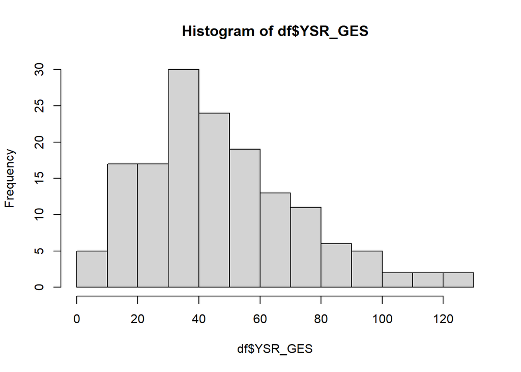

```r
hist(df$YSR_GES)
```

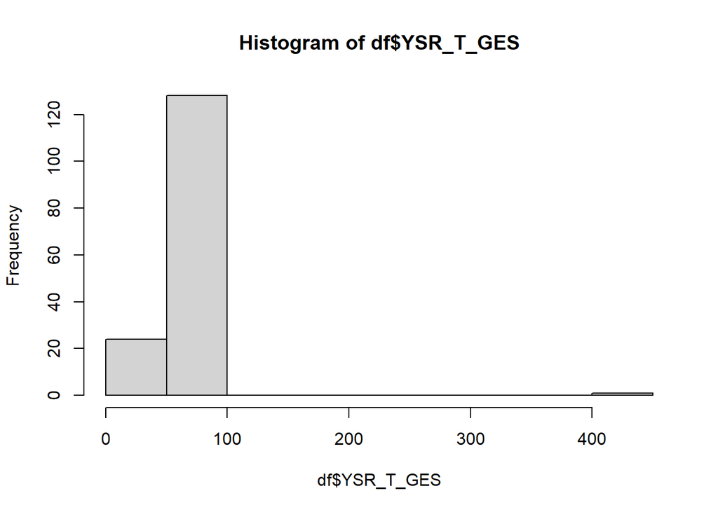

```r
hist(df$YSR_T_GES)
```

```r
df$YSR_T_GES[which(df$YSR_T_GES>100)]<-NA
df$YSR_T_GES[which(df$YSR_T_GES<25)]<-NA
```

### 1.4.2 create saliva change variable

```r
df$saliva_change<-df$saliva_Average.2-df$saliva_Average.1
```

### 1.4.3 recode group variable

```r
table(df$group)
```

```
## < table of extent 0 >
```

```r
df$group<-ifelse(df$Gruppe %in% c('AUT','ASD'),'ASD',df$Gruppe)
df$autism_boolean<-ifelse(df$group=='ASD',T,F)
```

### 1.4.4 logarithmize bio samples

```r
df$saliva_Average.1_log<-log10(df$saliva_Average.1)
df$saliva_Average.2_log<-log10(df$saliva_Average.2)
df$hair_cortisol_pg_mg_log<-log10(df$hair_cortisol_pg_mg)

df$saliva_change_log<-df$saliva_Average.2_log-df$saliva_Average.1_log
```

### 1.4.5 IQ estimate

```r
df$iq<-with(df,(iq_mt+iq_gf+iq_mz+iq_wt)/4)
```

### 1.4.6 calculate age

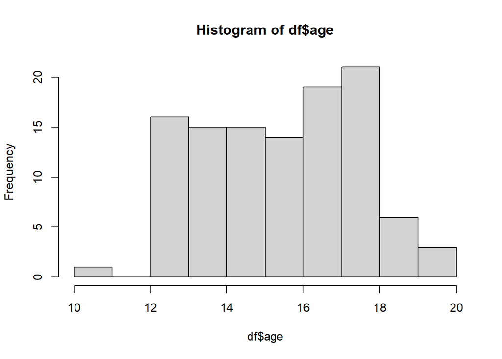

```r
df$Date<-as.Date(df$Date, format = "%m/%d/%y")
df$age<-as.numeric((df$Date-df$birth_date)/360)

hist(df$age)
```

### 1.4.7 estimate BMI

```r
df$BMI<-with(df,Gewicht.kg/(Groeße.cm/100*Groeße.cm/100))
```

### 1.4.8 pupil measure averages

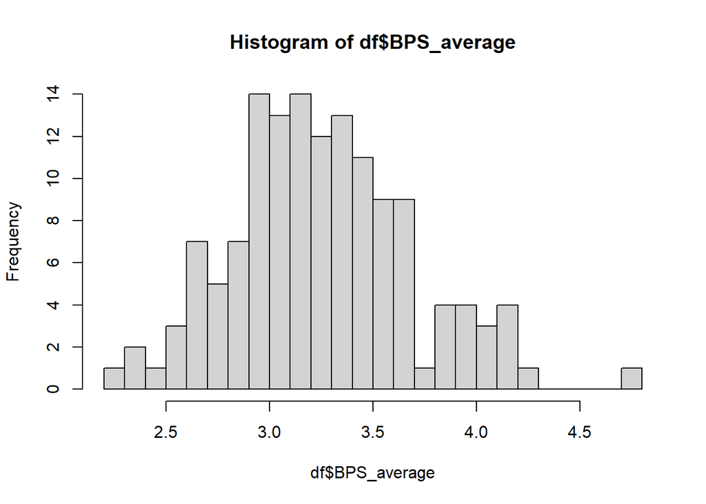

```r
df$BPS_average<-(df$pd_low_oddball_saliencehigh_utilityhigh+
  df$pd_low_oddball_saliencehigh_utilitylow+
  df$pd_low_oddball_saliencelow_utilityhigh+
  df$pd_low_oddball_saliencelow_utilitylow+
  df$BPS_Oddball_before_forward+
  df$BPS_Oddball_after_forward+
  df$BPS_Oddball_before_reverse+
  df$BPS_Oddball_after_reverse)/8


df$SEPR_average<-(df$rpd_oddball_saliencehigh_utilityhigh+
                    df$rpd_oddball_saliencehigh_utilitylow+
                    df$rpd_oddball_saliencelow_utilityhigh+
                    df$rpd_oddball_saliencelow_utilitylow+
                    df$SEPR_Oddball_after_forward+
                    df$SEPR_Oddball_after_reverse+
                    df$SEPR_Oddball_before_forward+
                    df$SEPR_Oddball_before_reverse)/8

hist(df$BPS_average,20)
```

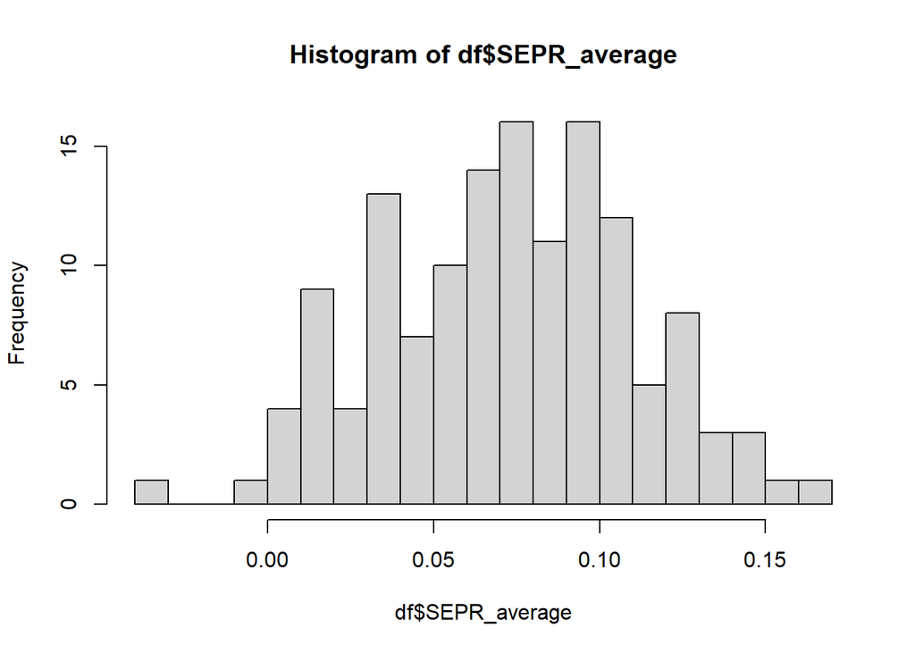

```r
hist(df$SEPR_average,20)
```

### 1.4.9 pupil size changes

```r
df$SEPR_Oddball_change<-df$SEPR_Oddball_after_forward-df$SEPR_Oddball_before_forward
df$BPS_change<-df$BPS_Standard_after_forward-df$BPS_Standard_before_forward
```

### 1.4.10 SDQ externalizing internalizing

```r
df$SDQ_self_int<-df$SDQ_emo_self+df$SDQ_beh_peers_self
df$SDQ_self_ext<-df$SDQ_beh_self+df$SDQ_hyp_self

df$SDQ_parent_int<-df$SDQ_emo_parent+df$SDQ_beh_peers_parent
df$SDQ_parent_ext<-df$SDQ_beh_parent+df$SDQ_hyp_parent
```

### 1.4.11 global externalizing internalizing

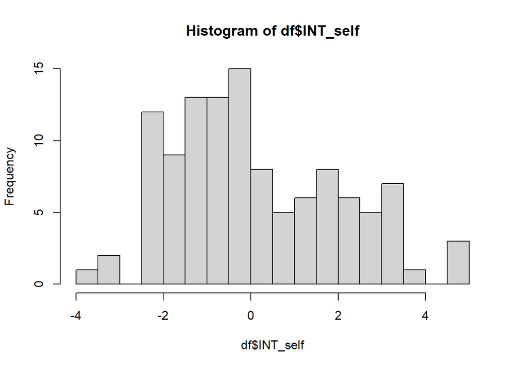

```r
df$INT_self<-rowMeans(scale(df$SDQ_self_int)+scale(df$YSR_T_INT))
df$EXT_self<-rowMeans(scale(df$SDQ_self_ext)+scale(df$YSR_T_EXT))

df$INT_parent<-rowMeans(scale(df$SDQ_parent_int)+scale(df$CBCL_T_INT))
df$EXT_parent<-rowMeans(scale(df$SDQ_parent_ext)+scale(df$CBCL_T_EXT))

hist(df$INT_self,20)
```

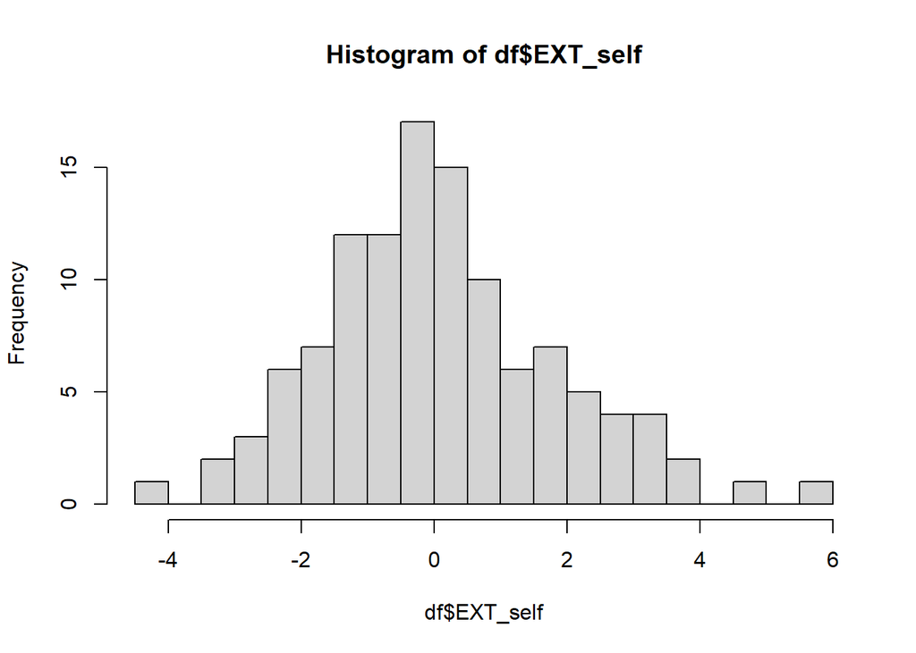

```r
hist(df$EXT_self,20)
```

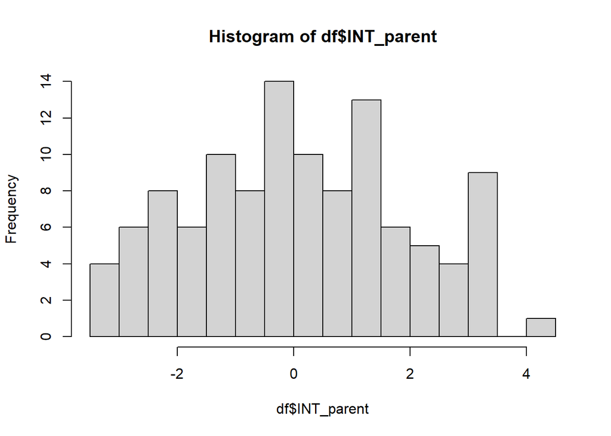

```r
hist(df$INT_parent,20)
```

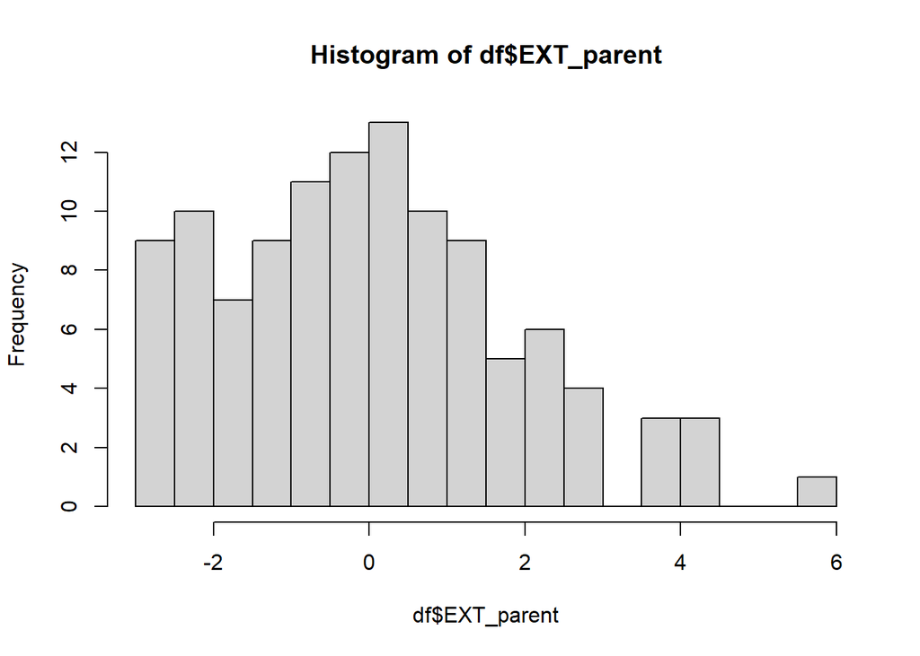

```r
hist(df$EXT_parent,20)
```

## 1.5 data quality

### 1.5.1 missing data

-complete data for CBCL -more missings in SDQ

```r
CBCL<-with(df,table(!is.na(CBCL_T_GES)))
YSR<-with(df,table(!is.na(YSR_T_GES)))

SDQ_self<-with(df,table(!is.na(SDQ_total_self)))
SDQ_parent<-with(df,table(!is.na(SDQ_total_parent)))

hair_cortisol<-with(df,table(!is.na(hair_cortisol_pg_mg)))
saliva_cortisol_measure1<-with(df,table(!is.na(saliva_Average.1)))
saliva_cortisol_measure2<-with(df,table(!is.na(saliva_Average.2)))

missing_table<-rbind(CBCL,YSR,SDQ_self,SDQ_parent,hair_cortisol,saliva_cortisol_measure1,saliva_cortisol_measure2)

missing_table %>%
  kbl(caption = "Available data for data modalities") %>%
  kable_classic(full_width = F, html_font = "Cambria")
```

Available data for data modalities

|  | FALSE | TRUE |
| --- | --- | --- |
| CBCL | 4 | 154 |
| YSR | 7 | 151 |
| SDQ_self | 42 | 116 |
| SDQ_parent | 44 | 114 |
| hair_cortisol | 51 | 107 |
| saliva_cortisol_measure1 | 49 | 109 |
| saliva_cortisol_measure2 | 53 | 105 |

```r
with(df,table(!is.na(CBCL_T_GES),!is.na(hair_cortisol_pg_mg)))
```

```
##
##         FALSE TRUE
##   FALSE     0    4
##   TRUE     51  103
```

```r
with(df,table(!is.na(SDQ_total_parent),!is.na(hair_cortisol_pg_mg)))
```

```
##
##         FALSE TRUE
##   FALSE    39    5
##   TRUE     12  102
```

### 1.5.2 participants by diagnosis and available biosamples

```r
table(df$group[!is.na(df$hair_cortisol_pg_mg) & !is.na(df$saliva_Average.1)])
```

```
##
## ADHD  ANG  ASD  CON  DEP  MHC
##   13    4   44   20   14    8
```

### 1.5.3 bio samples data quality

#### 1.5.3.1 hair cortisol

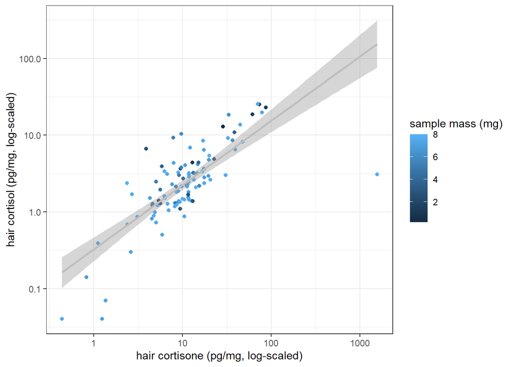

```r
ggplot(df,aes(x=hair_cortisone_pg_mg,y=hair_cortisol_pg_mg,color=hair_mass_mg))+
  geom_point()+
  labs(x='hair cortisone (pg/mg, log-scaled)', y='hair cortisol (pg/mg, log-scaled)', color='sample mass (mg)')+
  geom_smooth(color='grey',method='lm')+
  scale_x_continuous(trans='log10') +
  scale_y_continuous(trans='log10')
```

#### 1.5.3.2 saliva cortisol

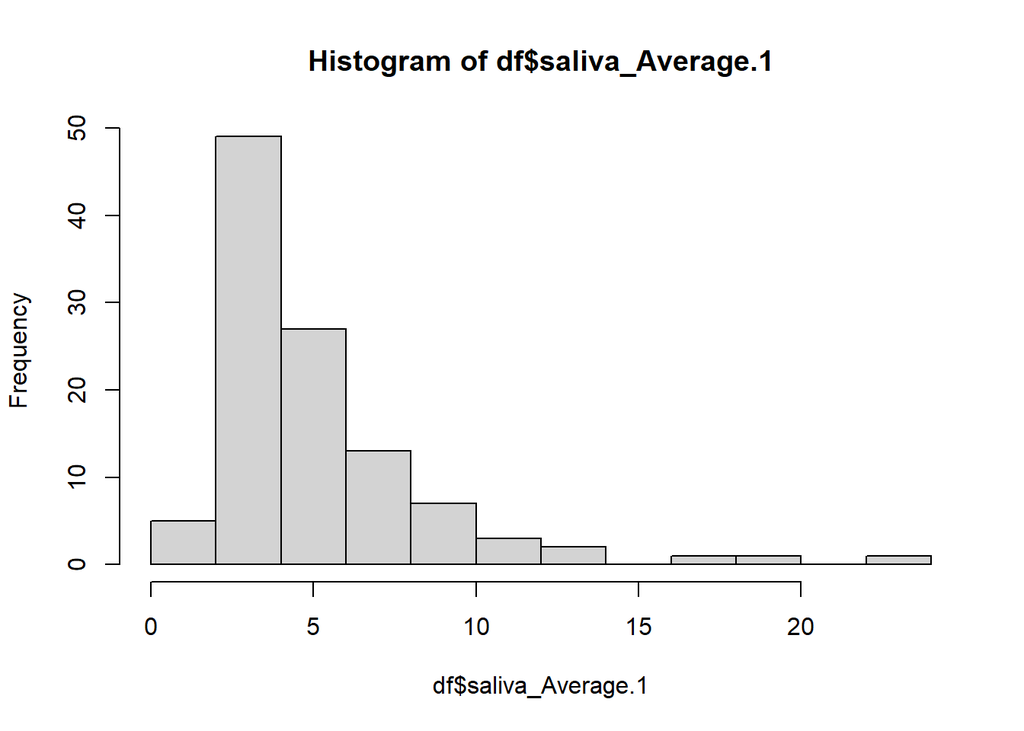

```r
hist(df$saliva_Average.1)
```

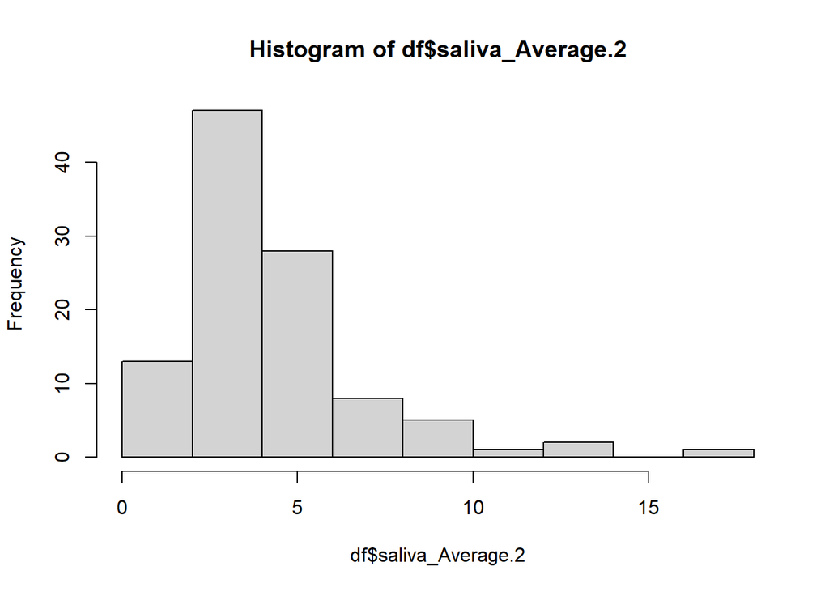

```r
hist(df$saliva_Average.2)
```

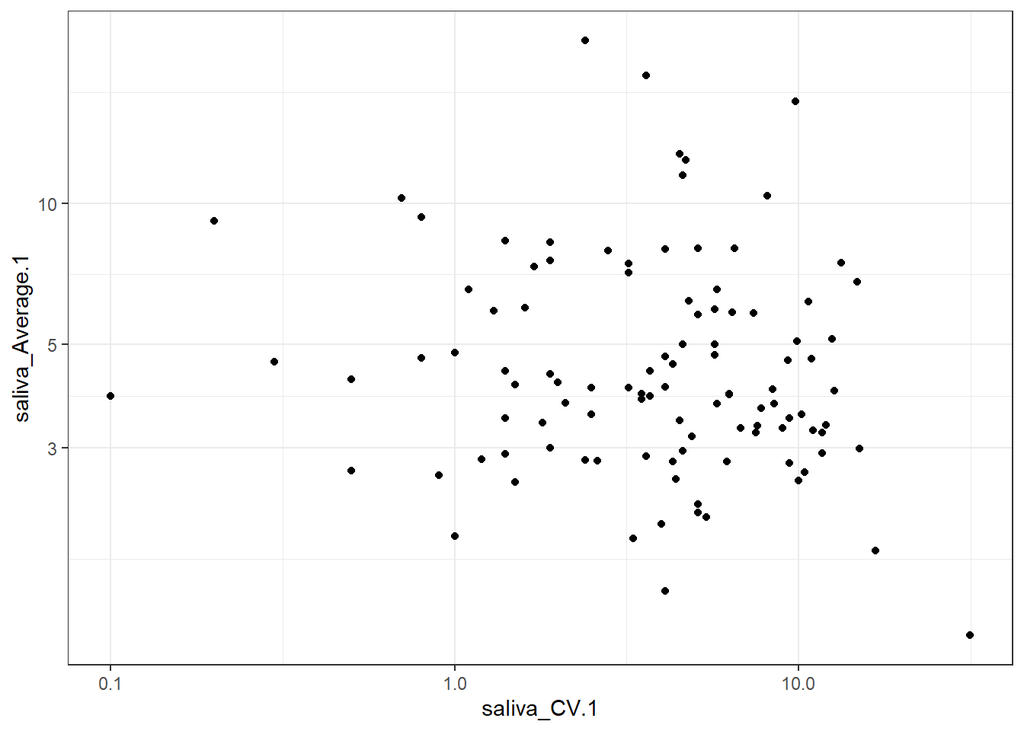

```r
ggplot(df,aes(y=saliva_Average.1,x=saliva_CV.1))+
  geom_point()+
  scale_x_continuous(trans='log10') +
  scale_y_continuous(trans='log10')
```

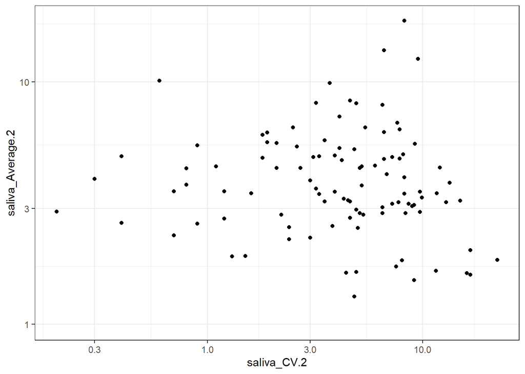

```r
ggplot(df,aes(y=saliva_Average.2,x=saliva_CV.2))+
  geom_point()+
  scale_x_continuous(trans='log10') +
  scale_y_continuous(trans='log10')
```

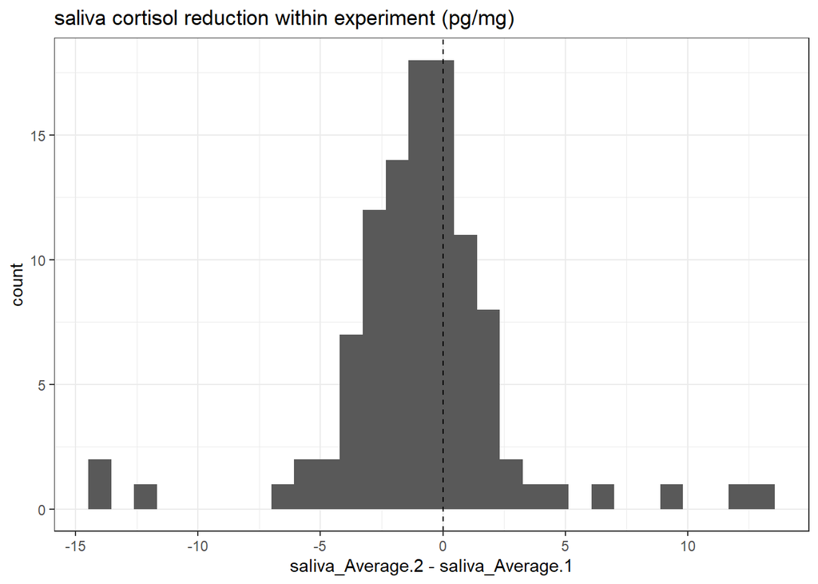

```r
ggplot(df,aes(x=saliva_Average.2-saliva_Average.1))+
  geom_histogram()+
  geom_vline(xintercept=0,linetype=2)+
  labs(title='saliva cortisol reduction within experiment (pg/mg)')
```

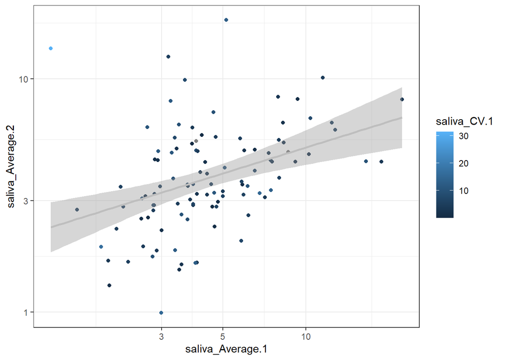

```r
ggplot(df,aes(x=saliva_Average.1,y=saliva_Average.2,color=saliva_CV.1))+
  geom_point()+
  geom_smooth(color='grey',method='lm')+
  #labs(x='hair cortisone (pg/mg, log-scaled)', y='hair cortisol (pg/mg, log-scaled)', color='sample mass (mg)')+
  scale_x_continuous(trans='log10') +
  scale_y_continuous(trans='log10')
```

### 1.5.4 questionnaire data

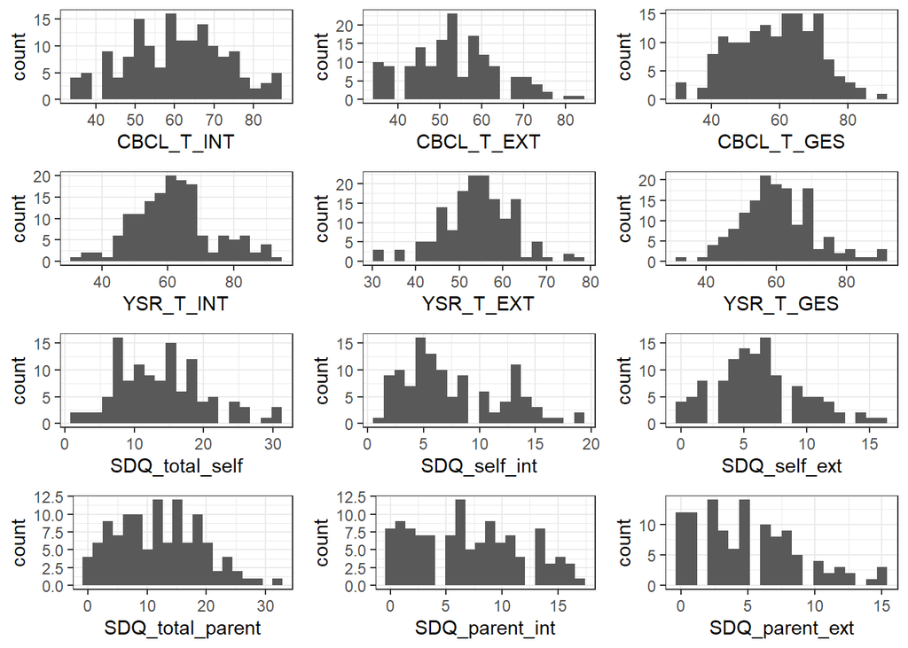

```r
#core questionnaire measures

grid.arrange(
  ggplot(df,aes(CBCL_T_INT,group=Gruppe))+geom_histogram(bins=20),
  ggplot(df,aes(CBCL_T_EXT,group=Gruppe))+geom_histogram(bins=20),
  ggplot(df,aes(CBCL_T_GES,group=Gruppe))+geom_histogram(bins=20),

  ggplot(df,aes(YSR_T_INT,group=Gruppe))+geom_histogram(bins=20),
  ggplot(df,aes(YSR_T_EXT,group=Gruppe))+geom_histogram(bins=20),
  ggplot(df,aes(YSR_T_GES,group=Gruppe))+geom_histogram(bins=20),

  ggplot(df,aes(SDQ_total_self,group=Gruppe))+geom_histogram(bins=20),
  ggplot(df,aes(SDQ_self_int,group=Gruppe))+geom_histogram(bins=20),
  ggplot(df,aes(SDQ_self_ext,group=Gruppe))+geom_histogram(bins=20),

  ggplot(df,aes(SDQ_total_parent,group=Gruppe))+geom_histogram(bins=20),
  ggplot(df,aes(SDQ_parent_int,group=Gruppe))+geom_histogram(bins=20),
  ggplot(df,aes(SDQ_parent_ext,group=Gruppe))+geom_histogram(bins=20)
)
```

### 1.5.5 bio samples

- suggests to log-transform variables in analysis

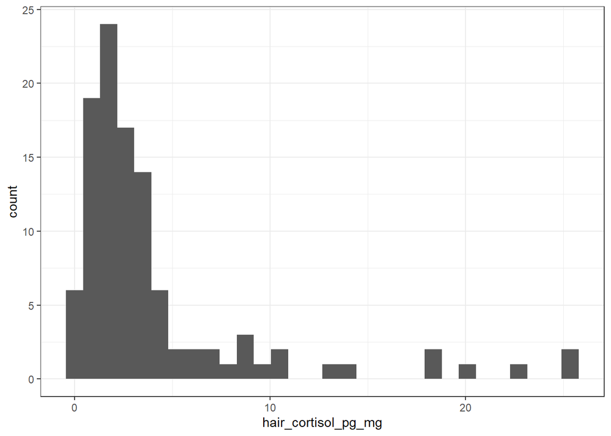

```r
ggplot(df,aes(hair_cortisol_pg_mg))+geom_histogram()
```

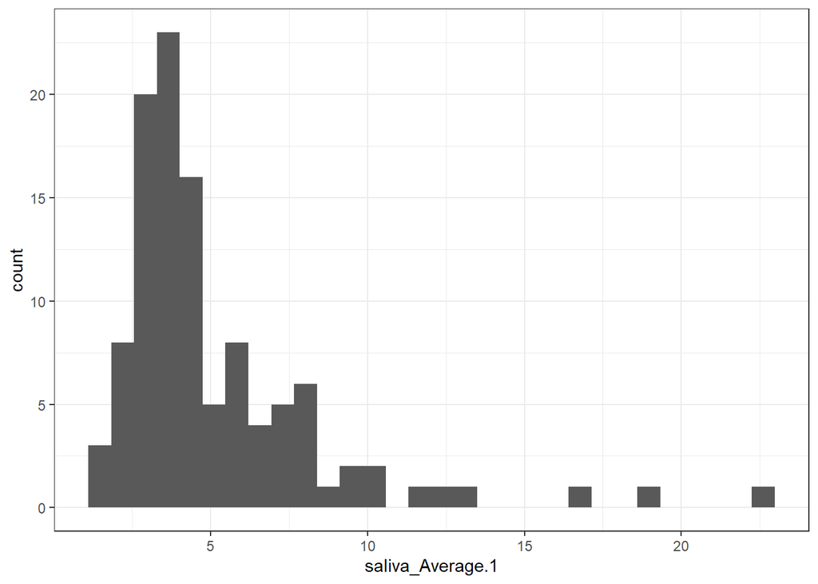

```r
ggplot(df,aes(saliva_Average.1))+geom_histogram()
```

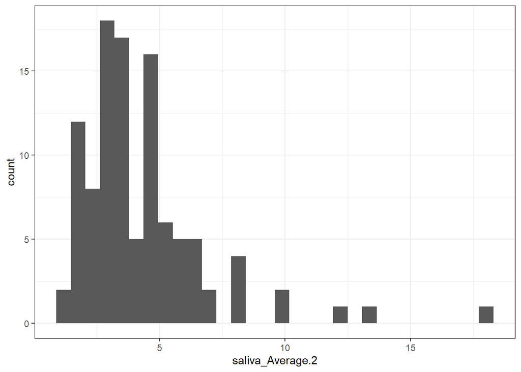

```r
ggplot(df,aes(saliva_Average.2))+geom_histogram()
```

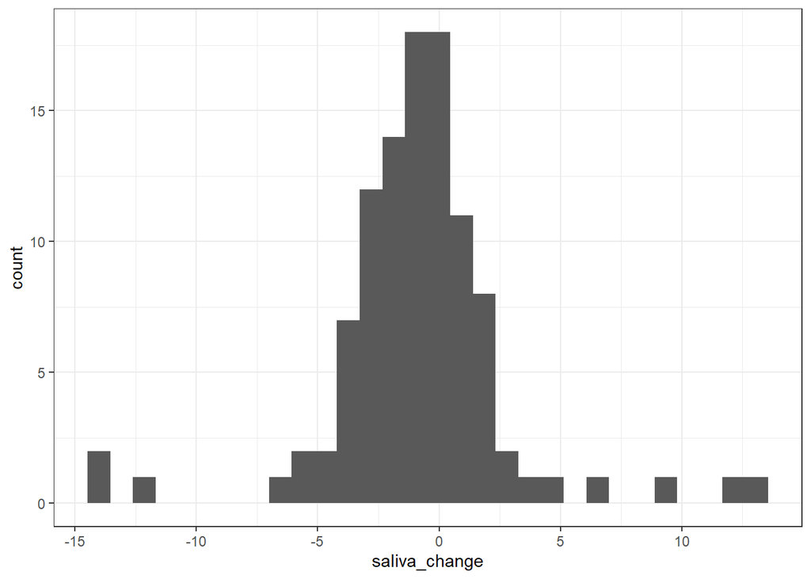

```r
ggplot(df,aes(saliva_change))+geom_histogram()
```

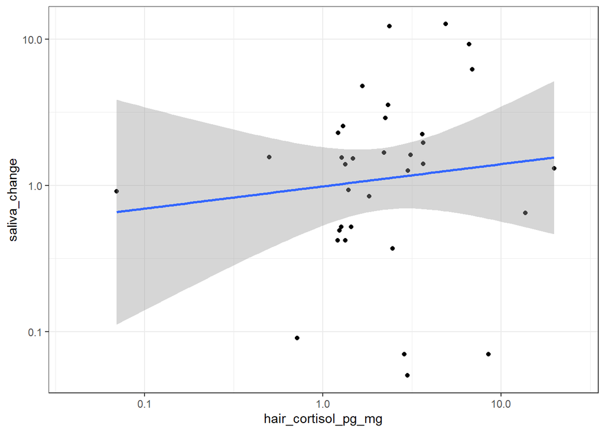

```r
ggplot(df,aes(x=hair_cortisol_pg_mg,y=saliva_change))+geom_point()+
  scale_x_continuous(trans='log10')+
  scale_y_continuous(trans='log10')+
  geom_smooth(method='lm')
```

### 1.5.6 covariates biosamples - influence of bio sample characteristics

- considering: time of day, saliva measurement error, BMI, age, gender
- higher saliva measurement error associated with lower saliva cortisol 1
- higher age associated with higher saliva cortisol 1
- higher hair mass associated with lower hair cortisol measure

–> time of day, gender, BMI is not associated with biosamples

```r
lm<-lm(saliva_Average.1_log~saliva_Time.1+saliva_CV.1+BMI+age+gender,df)
anova(lm)
```

```
## Analysis of Variance Table
##
## Response: saliva_Average.1_log
##               Df Sum Sq Mean Sq F value   Pr(>F)
## saliva_Time.1  1 0.1013 0.10127  2.2980 0.133005
## saliva_CV.1    1 0.3529 0.35285  8.0066 0.005734 **
## BMI            1 0.0347 0.03473  0.7881 0.377019
## age            1 0.3479 0.34786  7.8933 0.006074 **
## gender         1 0.0031 0.00305  0.0692 0.793034
## Residuals     91 4.0104 0.04407
## ---
## Signif. codes:  0 '***' 0.001 '**' 0.01 '*' 0.05 '.' 0.1 ' ' 1
```

```r
standardize_parameters(lm)
```

```
## # Standardization method: refit
##
## Parameter         | Std. Coef. |         95% CI
## -----------------------------------------------
## (Intercept)       |       0.02 | [-0.23,  0.28]
## saliva Time 1     |      -0.10 | [-0.29,  0.09]
## saliva CV 1       |      -0.25 | [-0.44, -0.06]
## BMI               |  -7.98e-04 | [-0.20,  0.20]
## age               |       0.29 | [ 0.09,  0.49]
## gender [weiblich] |      -0.05 | [-0.44,  0.34]
```

```r
anova(lm(saliva_Average.2_log~saliva_Time.2+saliva_CV.2+BMI+age+gender,df))
```

```
## Analysis of Variance Table
##
## Response: saliva_Average.2_log
##               Df Sum Sq  Mean Sq F value  Pr(>F)
## saliva_Time.2  1 0.0476 0.047619  1.0176 0.31579
## saliva_CV.2    1 0.1543 0.154282  3.2970 0.07274 .
## BMI            1 0.0014 0.001372  0.0293 0.86444
## age            1 0.0092 0.009210  0.1968 0.65837
## gender         1 0.0002 0.000241  0.0052 0.94292
## Residuals     90 4.2116 0.046795
## ---
## Signif. codes:  0 '***' 0.001 '**' 0.01 '*' 0.05 '.' 0.1 ' ' 1
```

```r
lm<-lm(hair_cortisol_pg_mg~hair_mass_mg+BMI+age+gender,df)
anova(lm)
```

```
## Analysis of Variance Table
##
## Response: hair_cortisol_pg_mg
##              Df  Sum Sq Mean Sq F value   Pr(>F)
## hair_mass_mg  1  265.50 265.496 10.8353 0.001404 **
## BMI           1    9.20   9.202  0.3756 0.541464
## age           1   87.81  87.810  3.5837 0.061427 .
## gender        1   29.04  29.043  1.1853 0.279062
## Residuals    94 2303.26  24.503
## ---
## Signif. codes:  0 '***' 0.001 '**' 0.01 '*' 0.05 '.' 0.1 ' ' 1
```

```r
standardize_parameters(lm)
```

```
## # Standardization method: refit
##
## Parameter         | Std. Coef. |         95% CI
## -----------------------------------------------
## (Intercept)       |      -0.10 | [-0.35,  0.16]
## hair mass mg      |      -0.29 | [-0.48, -0.09]
## BMI               |      -0.01 | [-0.22,  0.19]
## age               |       0.17 | [-0.04,  0.38]
## gender [weiblich] |       0.22 | [-0.18,  0.61]
```

### 1.5.7 covariates questionnaires

```r
#YSR - self report
lm<-lm(YSR_T_GES~age+gender+iq+autism_boolean,df)
anova(lm)
```

```
## Analysis of Variance Table
##
## Response: YSR_T_GES
##                Df  Sum Sq Mean Sq F value  Pr(>F)
## age             1    94.8   94.81  0.7703 0.38239
## gender          1   117.8  117.80  0.9571 0.33045
## iq              1     2.3    2.34  0.0190 0.89061
## autism_boolean  1   378.9  378.92  3.0786 0.08262 .
## Residuals      93 11446.5  123.08
## ---
## Signif. codes:  0 '***' 0.001 '**' 0.01 '*' 0.05 '.' 0.1 ' ' 1
```

```r
lm<-lm(YSR_T_INT~age+gender+iq+autism_boolean,df)
anova(lm)
```

```
## Analysis of Variance Table
##
## Response: YSR_T_INT
##                Df  Sum Sq Mean Sq F value  Pr(>F)
## age             1   536.1  536.11  3.1616 0.07862 .
## gender          1   348.5  348.51  2.0553 0.15500
## iq              1    19.2   19.22  0.1133 0.73712
## autism_boolean  1   253.5  253.53  1.4952 0.22447
## Residuals      94 15939.4  169.57
## ---
## Signif. codes:  0 '***' 0.001 '**' 0.01 '*' 0.05 '.' 0.1 ' ' 1
```

```r
lm<-lm(YSR_T_EXT~age+gender+iq+autism_boolean,df)
anova(lm)
```

```
## Analysis of Variance Table
##
## Response: YSR_T_EXT
##                Df Sum Sq Mean Sq F value Pr(>F)
## age             1    0.4   0.398  0.0055 0.9408
## gender          1   10.1  10.093  0.1405 0.7086
## iq              1    1.0   0.995  0.0138 0.9066
## autism_boolean  1   11.1  11.106  0.1546 0.6950
## Residuals      94 6751.5  71.824
```

```r
#CBCL - parent report
lm<-lm(CBCL_T_GES~age+gender+iq+autism_boolean,df)
anova(lm)
```

```
## Analysis of Variance Table
##
## Response: CBCL_T_GES
##                Df  Sum Sq Mean Sq F value   Pr(>F)
## age             1   384.7  384.70  3.1913 0.077256 .
## gender          1     9.1    9.09  0.0754 0.784221
## iq              1   735.5  735.47  6.1011 0.015313 *
## autism_boolean  1  1822.7 1822.66 15.1200 0.000188 ***
## Residuals      94 11331.4  120.55
## ---
## Signif. codes:  0 '***' 0.001 '**' 0.01 '*' 0.05 '.' 0.1 ' ' 1
```

```r
lm<-lm(CBCL_T_INT~age+gender+iq+autism_boolean,df)
anova(lm)
```

```
## Analysis of Variance Table
##
## Response: CBCL_T_INT
##                Df  Sum Sq Mean Sq F value    Pr(>F)
## age             1     2.6    2.56  0.0193 0.8897110
## gender          1    44.7   44.73  0.3376 0.5626372
## iq              1   165.5  165.48  1.2487 0.2666511
## autism_boolean  1  1533.0 1533.01 11.5682 0.0009866 ***
## Residuals      94 12456.8  132.52
## ---
## Signif. codes:  0 '***' 0.001 '**' 0.01 '*' 0.05 '.' 0.1 ' ' 1
```

```r
lm<-lm(CBCL_T_EXT~age+gender+iq+autism_boolean,df)
anova(lm)
```

```
## Analysis of Variance Table
##
## Response: CBCL_T_EXT
##                Df Sum Sq Mean Sq F value   Pr(>F)
## age             1  745.0  745.00  7.4429 0.007601 **
## gender          1    0.0    0.00  0.0000 0.997997
## iq              1  728.4  728.36  7.2766 0.008281 **
## autism_boolean  1  483.7  483.71  4.8324 0.030384 *
## Residuals      94 9409.0  100.10
## ---
## Signif. codes:  0 '***' 0.001 '**' 0.01 '*' 0.05 '.' 0.1 ' ' 1
```

```r
#SDQ - self report
lm<-lm(SDQ_self_int~age+gender+iq+autism_boolean,df)
anova(lm)
```

```
## Analysis of Variance Table
##
## Response: SDQ_self_int
##                Df  Sum Sq Mean Sq F value  Pr(>F)
## age             1   29.54  29.541  1.7546 0.18854
## gender          1   87.38  87.383  5.1901 0.02501 *
## iq              1    2.71   2.711  0.1610 0.68916
## autism_boolean  1   78.20  78.203  4.6448 0.03373 *
## Residuals      93 1565.79  16.836
## ---
## Signif. codes:  0 '***' 0.001 '**' 0.01 '*' 0.05 '.' 0.1 ' ' 1
```

```r
summary(lm)
```

```
##
## Call:
## lm(formula = SDQ_self_int ~ age + gender + iq + autism_boolean,
##     data = df)
##
## Residuals:
##     Min      1Q  Median      3Q     Max
## -8.3191 -2.7556 -0.2921  2.1892 10.9660
##
## Coefficients:
##                     Estimate Std. Error t value Pr(>|t|)
## (Intercept)         3.480432   5.532857   0.629  0.53086
## age                 0.161902   0.220562   0.734  0.46477
## genderweiblich      2.660095   0.927517   2.868  0.00511 **
## iq                 -0.000909   0.037527  -0.024  0.98073
## autism_booleanTRUE  1.984468   0.920787   2.155  0.03373 *
## ---
## Signif. codes:  0 '***' 0.001 '**' 0.01 '*' 0.05 '.' 0.1 ' ' 1
##
## Residual standard error: 4.103 on 93 degrees of freedom
##   (60 observations deleted due to missingness)
## Multiple R-squared:  0.1122, Adjusted R-squared:  0.07399
## F-statistic: 2.938 on 4 and 93 DF,  p-value: 0.02459
```

```r
lm<-lm(SDQ_self_ext~age+gender+iq+autism_boolean,df)
anova(lm)
```

```
## Analysis of Variance Table
##
## Response: SDQ_self_ext
##                Df  Sum Sq Mean Sq F value  Pr(>F)
## age             1   37.77  37.771  3.0256 0.08523 .
## gender          1   14.62  14.620  1.1711 0.28194
## iq              1   42.66  42.658  3.4171 0.06767 .
## autism_boolean  1   10.20  10.202  0.8172 0.36831
## Residuals      94 1173.48  12.484
## ---
## Signif. codes:  0 '***' 0.001 '**' 0.01 '*' 0.05 '.' 0.1 ' ' 1
```

```r
#SDQ - parent report
lm<-lm(SDQ_parent_int~age+gender+iq+autism_boolean,df)
anova(lm)
```

```
## Analysis of Variance Table
##
## Response: SDQ_parent_int
##                Df  Sum Sq Mean Sq F value    Pr(>F)
## age             1    1.19   1.186  0.0607 0.8059851
## gender          1    4.76   4.764  0.2437 0.6226747
## iq              1   61.49  61.491  3.1460 0.0793503 .
## autism_boolean  1  307.27 307.267 15.7205 0.0001432 ***
## Residuals      94 1837.29  19.546
## ---
## Signif. codes:  0 '***' 0.001 '**' 0.01 '*' 0.05 '.' 0.1 ' ' 1
```

```r
summary(lm)
```

```
##
## Call:
## lm(formula = SDQ_parent_int ~ age + gender + iq + autism_boolean,
##     data = df)
##
## Residuals:
##    Min     1Q Median     3Q    Max
## -8.636 -3.561 -0.117  2.809 10.959
##
## Coefficients:
##                    Estimate Std. Error t value Pr(>|t|)
## (Intercept)        10.19958    5.83940   1.747 0.083959 .
## age                -0.09802    0.23712  -0.413 0.680282
## genderweiblich      2.07872    0.99940   2.080 0.040250 *
## iq                 -0.03967    0.03848  -1.031 0.305247
## autism_booleanTRUE  3.90896    0.98589   3.965 0.000143 ***
## ---
## Signif. codes:  0 '***' 0.001 '**' 0.01 '*' 0.05 '.' 0.1 ' ' 1
##
## Residual standard error: 4.421 on 94 degrees of freedom
##   (59 observations deleted due to missingness)
## Multiple R-squared:  0.1694, Adjusted R-squared:  0.1341
## F-statistic: 4.793 on 4 and 94 DF,  p-value: 0.001458
```

```r
lm<-lm(SDQ_parent_ext~age+gender+iq+autism_boolean,df)
anova(lm)
```

```
## Analysis of Variance Table
##
## Response: SDQ_parent_ext
##                Df  Sum Sq Mean Sq F value    Pr(>F)
## age             1  191.44 191.438 16.3235 0.0001091 ***
## gender          1   45.74  45.738  3.9000 0.0512202 .
## iq              1   97.27  97.266  8.2937 0.0049268 **
## autism_boolean  1   63.47  63.471  5.4120 0.0221473 *
## Residuals      94 1102.41  11.728
## ---
## Signif. codes:  0 '***' 0.001 '**' 0.01 '*' 0.05 '.' 0.1 ' ' 1
```

```r
summary(lm)
```

```
##
## Call:
## lm(formula = SDQ_parent_ext ~ age + gender + iq + autism_boolean,
##     data = df)
##
## Residuals:
##      Min       1Q   Median       3Q      Max
## -10.0961  -2.3447  -0.4426   1.8023   8.7175
##
## Coefficients:
##                    Estimate Std. Error t value Pr(>|t|)
## (Intercept)        22.38841    4.52325   4.950 3.26e-06 ***
## age                -0.67838    0.18368  -3.693 0.000372 ***
## genderweiblich     -0.38902    0.77414  -0.503 0.616475
## iq                 -0.07195    0.02981  -2.414 0.017717 *
## autism_booleanTRUE  1.77661    0.76368   2.326 0.022147 *
## ---
## Signif. codes:  0 '***' 0.001 '**' 0.01 '*' 0.05 '.' 0.1 ' ' 1
##
## Residual standard error: 3.425 on 94 degrees of freedom
##   (59 observations deleted due to missingness)
## Multiple R-squared:  0.2652, Adjusted R-squared:  0.234
## F-statistic: 8.482 on 4 and 94 DF,  p-value: 6.897e-06
```

## 1.6 data analysis

### 1.6.1 collapse CBCL and SDQ measures

- does not suggest collapsing SDQ and CBCL/YSR reports of internalizing and externalizing

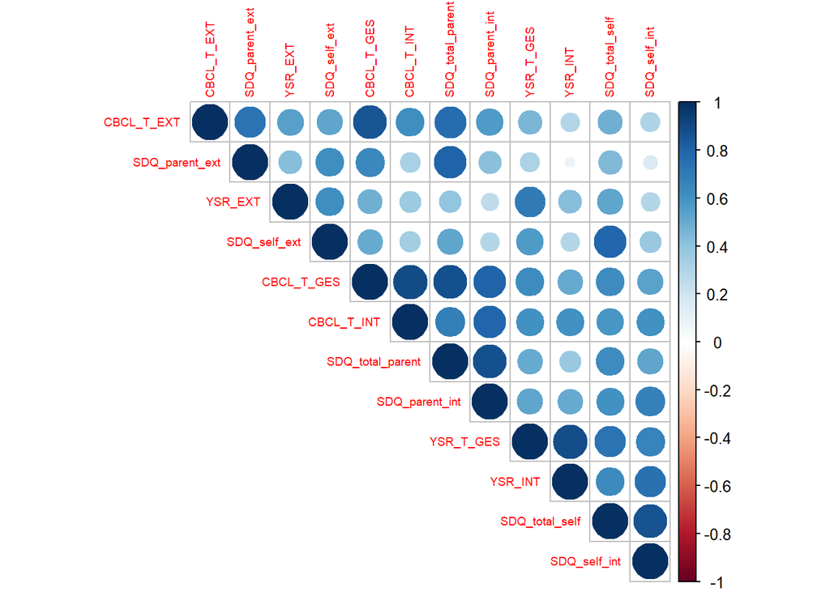

```r
interested_variables<-c(
  "YSR_T_GES",
  "YSR_INT",
  "YSR_EXT",
  "CBCL_T_GES",
  "CBCL_T_INT",
  "CBCL_T_EXT",
  "SDQ_total_self",
  "SDQ_self_int",
  "SDQ_self_ext",
  "SDQ_total_parent",
  "SDQ_parent_int",
  "SDQ_parent_ext"

)

cor_matrix<-round(cor(df[,interested_variables],use = 'pairwise.complete.obs'),2)
corrplot(cor_matrix,type='upper',order='hclust',tl.cex=0.6)
```

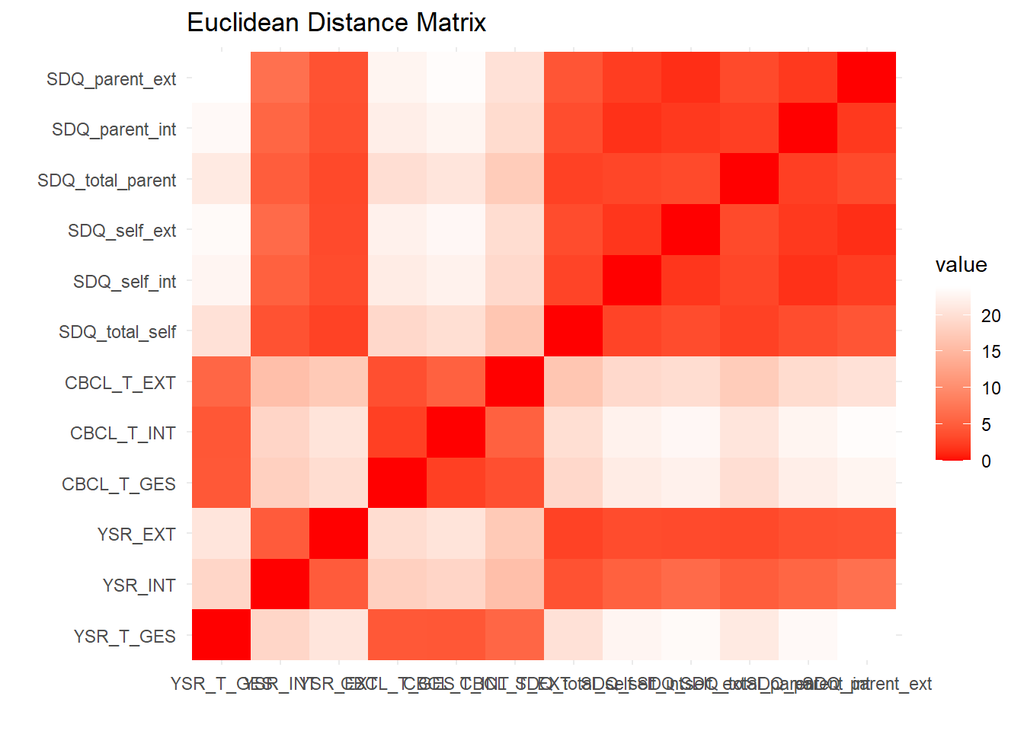

```r
df_cluster<-t(df[complete.cases(df[,interested_variables]),interested_variables])
df_cluster<-scale(df_cluster)
dist_matrix<-dist(df_cluster, method='euclidean')
dist_mat <- as.matrix(dist_matrix)


melted_dist <- reshape2::melt(dist_mat)
ggplot(melted_dist, aes(Var1, Var2, fill = value)) +
  geom_tile() +
  scale_fill_gradient(low = "red", high = "white") +
  theme_minimal() +
  labs(title = "Euclidean Distance Matrix", x = "", y = "")
```

### 1.6.2 correlation table

- saliva cortisol is negatively associated with baseline pupil sizes
- hair cortisol is negatively assoicated with self- and parent-reported internalizing
- SEPR average is negatively associated with self- and parent-reported externalizing
- BPS average is negatively associated with saliva cortisol

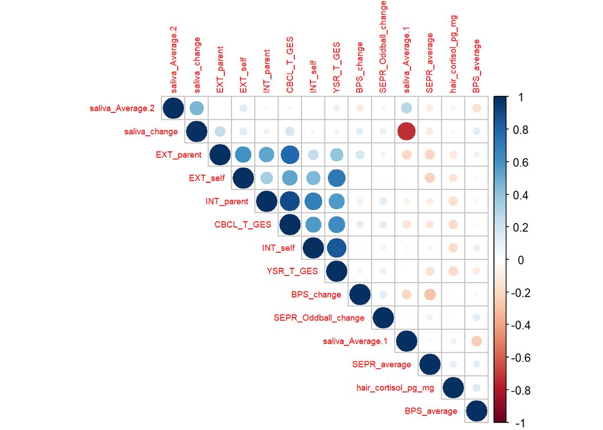

```r
interested_variables<-c(
  "saliva_Average.1",
  "saliva_Average.2",
  'saliva_change',
  "hair_cortisol_pg_mg",
  "BPS_change",
  'BPS_average',
  "SEPR_average",
  "SEPR_Oddball_change",
  "INT_parent",
  "EXT_parent",
  "CBCL_T_GES",
  "INT_self",
  "EXT_self",
  "YSR_T_GES"
)

cor_matrix<-round(cor(df[,interested_variables],use = 'pairwise.complete.obs'),2)
corrplot(cor_matrix,type='upper',order='hclust',tl.cex=0.6)
```

### 1.6.3 visualization

- higher psychopathology seems to be associated with attenuated saliva cortisol drop-off during the experiment

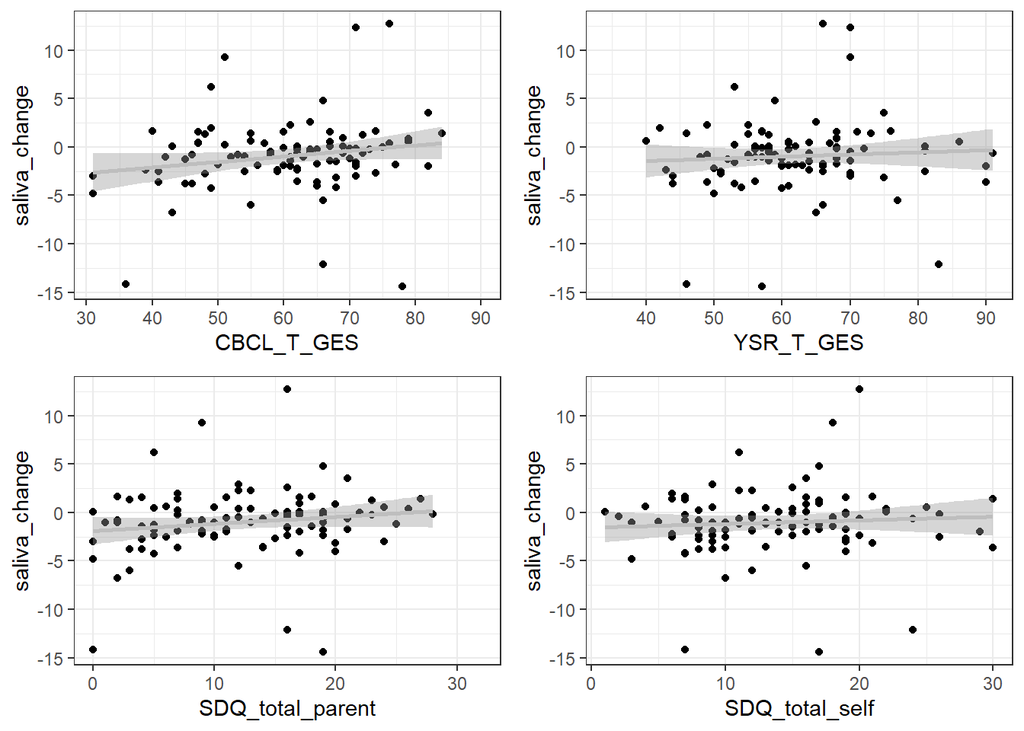

```r
grid.arrange(
ggplot(df,aes(x=CBCL_T_GES,y=saliva_change))+geom_point()+geom_smooth(color='grey',method='lm'),
ggplot(df,aes(x=YSR_T_GES,y=saliva_change))+geom_point()+geom_smooth(color='grey',method='lm'),
ggplot(df,aes(x=SDQ_total_parent,y=saliva_change))+geom_point()+geom_smooth(color='grey',method='lm'),
ggplot(df,aes(x=SDQ_total_self,y=saliva_change))+geom_point()+geom_smooth(color='grey',method='lm')
)
```

### 1.6.4 effect of psychopathology on cortisol

- higher self-reported psychopathology is associated with attenuated hair cortisol (hypocortisolism)
- even when controlling for autism symptoms in the autism-enriched sample
- can be attributed to internalizing versus externalizing symptoms
- also after controlling for relevant covariates

```r
#customaized ANOVA output
analyze_lm<-function(x,log_backtransform=F){
  print(car::Anova(x,type=3))
  return(cbind(round(summary(x)$coefficients[,1],2),round(confint(x),2)))

  if(log_backtransform){
  return(cbind(round(10^summary(x)$coefficients[,1],2),round(10^confint(x),2)))
  }

}

#scale numeric variables
df_scaled<-as.data.frame(lapply(df, function(x) {if (is.numeric(x)) scale(x) else x}))

lm<-lm(saliva_Average.1_log~CBCL_T_GES+age+saliva_CV.1+autism_boolean,data=df_scaled)
analyze_lm(lm,log_backtransform = T)
```

```
## Anova Table (Type III tests)
##
## Response: saliva_Average.1_log
##                Sum Sq Df F value   Pr(>F)
## (Intercept)     0.062  1  0.0679 0.795022
## CBCL_T_GES      0.692  1  0.7631 0.384531
## age            10.822  1 11.9338 0.000819 ***
## saliva_CV.1     3.937  1  4.3414 0.039826 *
## autism_boolean  0.077  1  0.0850 0.771226
## Residuals      87.963 97
## ---
## Signif. codes:  0 '***' 0.001 '**' 0.01 '*' 0.05 '.' 0.1 ' ' 1
```

```
##                          2.5 % 97.5 %
## (Intercept)        -0.03 -0.28   0.22
## CBCL_T_GES         -0.10 -0.32   0.12
## age                 0.34  0.15   0.54
## saliva_CV.1        -0.20 -0.39  -0.01
## autism_booleanTRUE  0.06 -0.35   0.48
```

```r
lm<-lm(saliva_Average.1_log~SDQ_total_parent+age+saliva_CV.1+autism_boolean,data=df_scaled)
analyze_lm(lm,log_backtransform = T)
```

```
## Anova Table (Type III tests)
##
## Response: saliva_Average.1_log
##                  Sum Sq Df F value   Pr(>F)
## (Intercept)       0.000  1  0.0001 0.990459
## SDQ_total_parent  1.248  1  1.4051 0.238765
## age               8.902  1 10.0201 0.002069 **
## saliva_CV.1       0.720  1  0.8105 0.370212
## autism_boolean    0.010  1  0.0116 0.914315
## Residuals        86.176 97
## ---
## Signif. codes:  0 '***' 0.001 '**' 0.01 '*' 0.05 '.' 0.1 ' ' 1
```

```
##                          2.5 % 97.5 %
## (Intercept)         0.00 -0.27   0.26
## SDQ_total_parent   -0.13 -0.35   0.09
## age                 0.31  0.11   0.50
## saliva_CV.1        -0.11 -0.34   0.13
## autism_booleanTRUE  0.02 -0.41   0.45
```

```r
lm<-lm(saliva_Average.1_log~YSR_T_GES+age+saliva_CV.1+autism_boolean,data=df_scaled)
analyze_lm(lm,log_backtransform = T)
```

```
## Anova Table (Type III tests)
##
## Response: saliva_Average.1_log
##                Sum Sq Df F value    Pr(>F)
## (Intercept)     0.021  1  0.0245 0.8760699
## YSR_T_GES       0.000  1  0.0002 0.9884527
## age            10.825  1 12.5718 0.0006099 ***
## saliva_CV.1     5.402  1  6.2738 0.0139570 *
## autism_boolean  0.019  1  0.0216 0.8834926
## Residuals      81.798 95
## ---
## Signif. codes:  0 '***' 0.001 '**' 0.01 '*' 0.05 '.' 0.1 ' ' 1
```

```
##                          2.5 % 97.5 %
## (Intercept)         0.02 -0.22   0.26
## YSR_T_GES           0.00 -0.18   0.18
## age                 0.35  0.16   0.55
## saliva_CV.1        -0.23 -0.42  -0.05
## autism_booleanTRUE -0.03 -0.41   0.35
```

```r
lm<-lm(saliva_Average.1_log~SDQ_total_self+age+saliva_CV.1+autism_boolean,data=df_scaled)
analyze_lm(lm,log_backtransform = T)
```

```
## Anova Table (Type III tests)
##
## Response: saliva_Average.1_log
##                Sum Sq Df F value   Pr(>F)
## (Intercept)     0.048  1  0.0534 0.817733
## SDQ_total_self  0.001  1  0.0010 0.975441
## age             9.066  1 10.0865 0.002003 **
## saliva_CV.1     1.103  1  1.2274 0.270649
## autism_boolean  0.192  1  0.2131 0.645379
## Residuals      87.186 97
## ---
## Signif. codes:  0 '***' 0.001 '**' 0.01 '*' 0.05 '.' 0.1 ' ' 1
```

```
##                          2.5 % 97.5 %
## (Intercept)         0.03 -0.22   0.28
## SDQ_total_self      0.00 -0.20   0.20
## age                 0.31  0.12   0.50
## saliva_CV.1        -0.13 -0.36   0.10
## autism_booleanTRUE -0.09 -0.49   0.30
```

```r
lm<-lm(saliva_change~CBCL_T_GES+age+saliva_CV.1+autism_boolean,data=df_scaled)
analyze_lm(lm)
```

```
## Anova Table (Type III tests)
##
## Response: saliva_change
##                Sum Sq Df F value   Pr(>F)
## (Intercept)     0.365  1  0.4184 0.519351
## CBCL_T_GES      1.225  1  1.4063 0.238693
## age             7.191  1  8.2523 0.005042 **
## saliva_CV.1     8.142  1  9.3440 0.002921 **
## autism_boolean  1.667  1  1.9133 0.169911
## Residuals      81.034 93
## ---
## Signif. codes:  0 '***' 0.001 '**' 0.01 '*' 0.05 '.' 0.1 ' ' 1
```

```
##                          2.5 % 97.5 %
## (Intercept)         0.08 -0.17   0.33
## CBCL_T_GES          0.13 -0.09   0.35
## age                -0.29 -0.48  -0.09
## saliva_CV.1         0.29  0.10   0.48
## autism_booleanTRUE -0.29 -0.70   0.13
```

```r
lm<-lm(saliva_change~SDQ_total_parent+age+saliva_CV.1+autism_boolean,data=df_scaled)
analyze_lm(lm)
```

```
## Anova Table (Type III tests)
##
## Response: saliva_change
##                  Sum Sq Df F value   Pr(>F)
## (Intercept)       0.155  1  0.1828 0.669937
## SDQ_total_parent  0.841  1  0.9894 0.322465
## age               6.050  1  7.1171 0.009008 **
## saliva_CV.1       2.441  1  2.8721 0.093472 .
## autism_boolean    0.803  1  0.9443 0.333688
## Residuals        79.051 93
## ---
## Signif. codes:  0 '***' 0.001 '**' 0.01 '*' 0.05 '.' 0.1 ' ' 1
```

```
##                          2.5 % 97.5 %
## (Intercept)         0.06 -0.21   0.32
## SDQ_total_parent    0.11 -0.11   0.33
## age                -0.26 -0.45  -0.07
## saliva_CV.1         0.20 -0.03   0.43
## autism_booleanTRUE -0.21 -0.64   0.22
```

```r
lm<-lm(saliva_change~YSR_T_GES+gender+age+saliva_CV.1+autism_boolean,data=df_scaled)
analyze_lm(lm)
```

```
## Anova Table (Type III tests)
##
## Response: saliva_change
##                Sum Sq Df F value   Pr(>F)
## (Intercept)     0.301  1  0.3325 0.565629
## YSR_T_GES       0.318  1  0.3516 0.554689
## gender          0.187  1  0.2066 0.650524
## age             7.922  1  8.7522 0.003951 **
## saliva_CV.1     9.431  1 10.4196 0.001740 **
## autism_boolean  1.144  1  1.2642 0.263848
## Residuals      81.462 90
## ---
## Signif. codes:  0 '***' 0.001 '**' 0.01 '*' 0.05 '.' 0.1 ' ' 1
```

```
##                          2.5 % 97.5 %
## (Intercept)         0.10 -0.25   0.46
## YSR_T_GES           0.06 -0.13   0.25
## genderweiblich     -0.10 -0.53   0.33
## age                -0.31 -0.52  -0.10
## saliva_CV.1         0.31  0.12   0.50
## autism_booleanTRUE -0.24 -0.67   0.18
```

```r
lm<-lm(saliva_change~SDQ_total_self+age+saliva_CV.1+autism_boolean,data=df_scaled)
analyze_lm(lm)
```

```
## Anova Table (Type III tests)
##
## Response: saliva_change
##                Sum Sq Df F value  Pr(>F)
## (Intercept)     0.010  1  0.0121 0.91277
## SDQ_total_self  0.214  1  0.2505 0.61789
## age             7.266  1  8.5089 0.00443 **
## saliva_CV.1     2.330  1  2.7288 0.10193
## autism_boolean  0.412  1  0.4824 0.48908
## Residuals      79.419 93
## ---
## Signif. codes:  0 '***' 0.001 '**' 0.01 '*' 0.05 '.' 0.1 ' ' 1
```

```
##                          2.5 % 97.5 %
## (Intercept)         0.01 -0.24   0.26
## SDQ_total_self      0.05 -0.15   0.25
## age                -0.28 -0.47  -0.09
## saliva_CV.1         0.19 -0.04   0.41
## autism_booleanTRUE -0.14 -0.53   0.26
```

```r
lm<-lm(hair_cortisol_pg_mg_log~CBCL_T_GES+age+hair_mass_mg+autism_boolean,data=df_scaled)
analyze_lm(lm,log_backtransform = T)
```

```
## Anova Table (Type III tests)
##
## Response: hair_cortisol_pg_mg_log
##                Sum Sq Df F value  Pr(>F)
## (Intercept)     0.934  1  1.0752 0.30242
## CBCL_T_GES      0.624  1  0.7186 0.39875
## age             1.669  1  1.9216 0.16892
## hair_mass_mg    4.902  1  5.6444 0.01952 *
## autism_boolean  0.975  1  1.1227 0.29203
## Residuals      82.506 95
## ---
## Signif. codes:  0 '***' 0.001 '**' 0.01 '*' 0.05 '.' 0.1 ' ' 1
```

```
##                          2.5 % 97.5 %
## (Intercept)         0.13 -0.12   0.37
## CBCL_T_GES         -0.09 -0.30   0.12
## age                 0.14 -0.06   0.34
## hair_mass_mg       -0.22 -0.41  -0.04
## autism_booleanTRUE -0.22 -0.62   0.19
```

```r
lm<-lm(hair_cortisol_pg_mg_log~YSR_T_GES+age+hair_mass_mg+autism_boolean,data=df_scaled)
analyze_lm(lm,log_backtransform = T)
```

```
## Anova Table (Type III tests)
##
## Response: hair_cortisol_pg_mg_log
##                Sum Sq Df F value   Pr(>F)
## (Intercept)     2.384  1  3.4816 0.065205 .
## YSR_T_GES       4.033  1  5.8899 0.017155 *
## age             4.497  1  6.5685 0.011985 *
## hair_mass_mg    4.796  1  7.0039 0.009551 **
## autism_boolean  1.569  1  2.2913 0.133494
## Residuals      63.677 93
## ---
## Signif. codes:  0 '***' 0.001 '**' 0.01 '*' 0.05 '.' 0.1 ' ' 1
```

```
##                          2.5 % 97.5 %
## (Intercept)         0.21 -0.01   0.43
## YSR_T_GES          -0.20 -0.37  -0.04
## age                 0.23  0.05   0.42
## hair_mass_mg       -0.22 -0.39  -0.06
## autism_booleanTRUE -0.26 -0.61   0.08
```

```r
lm<-lm(hair_cortisol_pg_mg_log~SDQ_total_parent+age+hair_mass_mg+autism_boolean,data=df_scaled)
analyze_lm(lm,log_backtransform = T)
```

```
## Anova Table (Type III tests)
##
## Response: hair_cortisol_pg_mg_log
##                  Sum Sq Df F value  Pr(>F)
## (Intercept)       0.657  1  0.7586 0.38595
## SDQ_total_parent  0.845  1  0.9758 0.32574
## age               1.475  1  1.7020 0.19518
## hair_mass_mg      5.236  1  6.0439 0.01577 *
## autism_boolean    0.790  1  0.9113 0.34219
## Residuals        82.304 95
## ---
## Signif. codes:  0 '***' 0.001 '**' 0.01 '*' 0.05 '.' 0.1 ' ' 1
```

```
##                          2.5 % 97.5 %
## (Intercept)         0.11 -0.14   0.36
## SDQ_total_parent   -0.10 -0.32   0.11
## age                 0.13 -0.07   0.33
## hair_mass_mg       -0.24 -0.43  -0.05
## autism_booleanTRUE -0.20 -0.61   0.22
```

```r
lm<-lm(hair_cortisol_pg_mg_log~SDQ_total_self+age+hair_mass_mg+autism_boolean,data=df_scaled)
analyze_lm(lm,log_backtransform = T)
```

```
## Anova Table (Type III tests)
##
## Response: hair_cortisol_pg_mg_log
##                Sum Sq Df F value   Pr(>F)
## (Intercept)     0.629  1  0.7873 0.377146
## SDQ_total_self  6.762  1  8.4605 0.004519 **
## age             2.255  1  2.8211 0.096321 .
## hair_mass_mg    7.522  1  9.4117 0.002809 **
## autism_boolean  0.577  1  0.7223 0.397517
## Residuals      75.928 95
## ---
## Signif. codes:  0 '***' 0.001 '**' 0.01 '*' 0.05 '.' 0.1 ' ' 1
```

```
##                          2.5 % 97.5 %
## (Intercept)         0.11 -0.13   0.34
## SDQ_total_self     -0.28 -0.46  -0.09
## age                 0.16 -0.03   0.35
## hair_mass_mg       -0.28 -0.47  -0.10
## autism_booleanTRUE -0.16 -0.53   0.21
```

```r
lm<-lm(hair_cortisol_pg_mg_log~YSR_T_INT+YSR_T_EXT+age+hair_mass_mg+autism_boolean,data=df_scaled)
analyze_lm(lm,log_backtransform = T)
```

```
## Anova Table (Type III tests)
##
## Response: hair_cortisol_pg_mg_log
##                Sum Sq Df F value   Pr(>F)
## (Intercept)     1.432  1  1.8166 0.180955
## YSR_T_INT       7.874  1  9.9895 0.002119 **
## YSR_T_EXT       0.264  1  0.3347 0.564270
## age             3.932  1  4.9880 0.027895 *
## hair_mass_mg    7.271  1  9.2236 0.003092 **
## autism_boolean  1.238  1  1.5703 0.213270
## Residuals      74.098 94
## ---
## Signif. codes:  0 '***' 0.001 '**' 0.01 '*' 0.05 '.' 0.1 ' ' 1
```

```
##                          2.5 % 97.5 %
## (Intercept)         0.16 -0.08   0.39
## YSR_T_INT          -0.31 -0.51  -0.12
## YSR_T_EXT           0.06 -0.14   0.25
## age                 0.22  0.02   0.42
## hair_mass_mg       -0.28 -0.46  -0.10
## autism_booleanTRUE -0.23 -0.59   0.13
```

```r
lm<-lm(hair_cortisol_pg_mg_log~SDQ_self_int+SDQ_self_ext+age+hair_mass_mg+autism_boolean,data=df)
analyze_lm(lm,log_backtransform = T)
```

```
## Anova Table (Type III tests)
##
## Response: hair_cortisol_pg_mg_log
##                 Sum Sq Df F value   Pr(>F)
## (Intercept)     0.2540  1  1.2916 0.258667
## SDQ_self_int    1.4455  1  7.3506 0.007985 **
## SDQ_self_ext    0.0612  1  0.3113 0.578229
## age             0.7055  1  3.5875 0.061323 .
## hair_mass_mg    2.0507  1 10.4278 0.001716 **
## autism_boolean  0.1136  1  0.5774 0.449243
## Residuals      18.2889 93
## ---
## Signif. codes:  0 '***' 0.001 '**' 0.01 '*' 0.05 '.' 0.1 ' ' 1
```

```
##                          2.5 % 97.5 %
## (Intercept)         0.49 -0.37   1.36
## SDQ_self_int       -0.03 -0.06  -0.01
## SDQ_self_ext       -0.01 -0.04   0.02
## age                 0.05  0.00   0.09
## hair_mass_mg       -0.07 -0.12  -0.03
## autism_booleanTRUE -0.07 -0.26   0.11
```

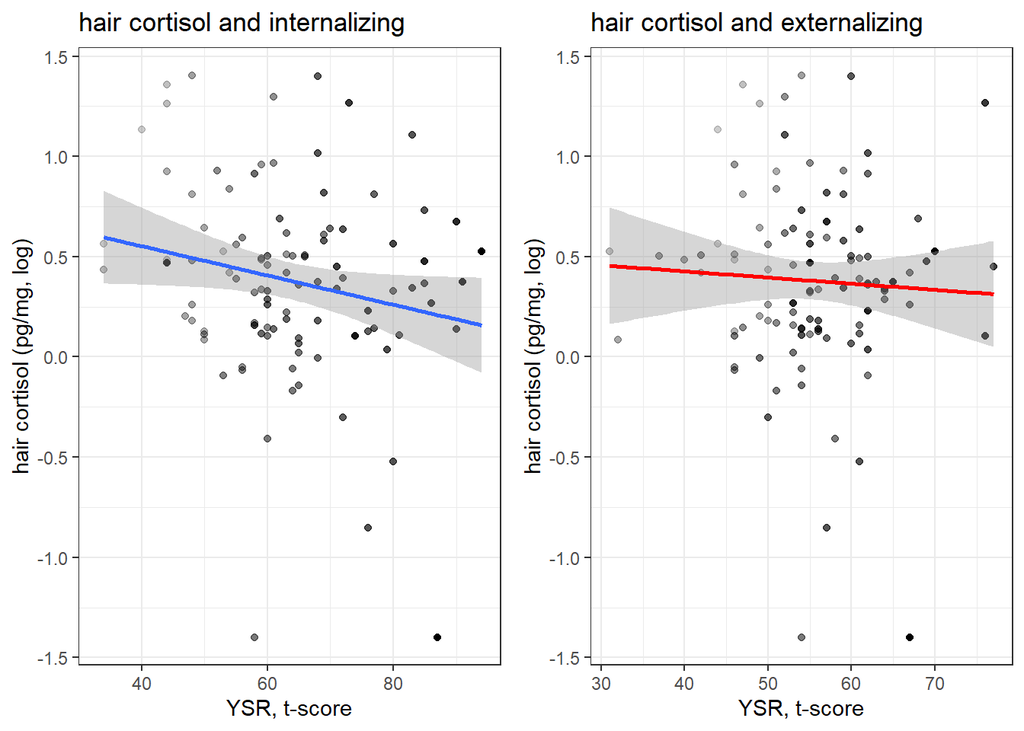

```r
grid.arrange(
ggplot(df,aes(x=YSR_T_INT,y=hair_cortisol_pg_mg_log,alpha=YSR_T_GES))+geom_point()+geom_smooth(method='lm')+
  labs(title='hair cortisol and internalizing')+xlab('YSR, t-score')+ylab('hair cortisol (pg/mg, log)')+ theme(legend.position="none"),
ggplot(df,aes(x=YSR_T_EXT,y=hair_cortisol_pg_mg_log,alpha=YSR_T_GES))+geom_point()+geom_smooth(method='lm',col='red')+
    labs(title='hair cortisol and externalizing')+xlab('YSR, t-score')+ylab('hair cortisol (pg/mg, log)')+ theme(legend.position="none"),
ncol=2)
```

### 1.6.5 effect of pupillary measures on psychopathology

- TODO: look into linear MIXED model
- SEPR Oddball change: change in SEPR to experimental manipulation handgrip
- high self-reported externalizing is associated with higher SEPR oddball change, if interlazing is above average

```r
cor.test(df$YSR_T_INT,df$YSR_T_EXT)
```

```
##
##  Pearson's product-moment correlation
##
## data:  df$YSR_T_INT and df$YSR_T_EXT
## t = 6.5015, df = 151, p-value = 1.095e-09
## alternative hypothesis: true correlation is not equal to 0
## 95 percent confidence interval:
##  0.3337510 0.5830719
## sample estimates:
##       cor
## 0.4676622
```

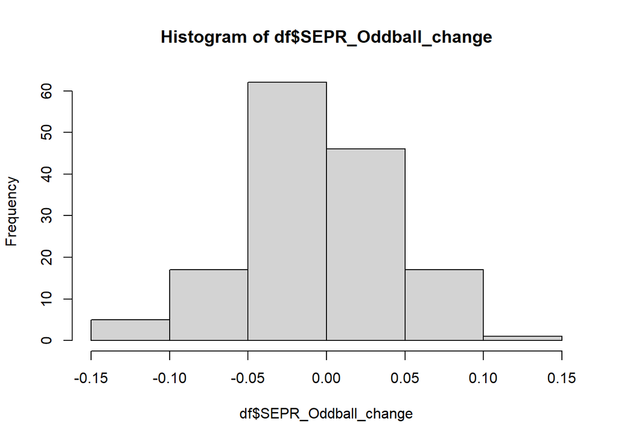

```r
hist(df$SEPR_Oddball_change)
```

```r
#scale numeric variables
df_scaled<-as.data.frame(lapply(df, function(x) {if (is.numeric(x)) scale(x) else x}))

lm<-lm(BPS_average~YSR_T_INT*YSR_T_EXT+
         +age+autism_boolean,data=df_scaled)
analyze_lm(lm)
```

```
## Anova Table (Type III tests)
##
## Response: BPS_average
##                     Sum Sq Df F value  Pr(>F)
## (Intercept)          0.013  1  0.0178 0.89430
## YSR_T_INT            1.081  1  1.4399 0.23333
## YSR_T_EXT            0.210  1  0.2790 0.59867
## age                  2.477  1  3.2978 0.07274 .
## autism_boolean       1.296  1  1.7257 0.19233
## YSR_T_INT:YSR_T_EXT  0.319  1  0.4241 0.51656
## Residuals           66.837 89
## ---
## Signif. codes:  0 '***' 0.001 '**' 0.01 '*' 0.05 '.' 0.1 ' ' 1
```

```
##                           2.5 % 97.5 %
## (Intercept)          0.02 -0.23   0.26
## YSR_T_INT            0.11 -0.07   0.30
## YSR_T_EXT           -0.05 -0.26   0.15
## age                 -0.18 -0.37   0.02
## autism_booleanTRUE  -0.25 -0.62   0.13
## YSR_T_INT:YSR_T_EXT  0.06 -0.12   0.24
```

```r
lm<-lm(BPS_change~YSR_T_INT*YSR_T_EXT+
         age+autism_boolean,data=df_scaled)
analyze_lm(lm)
```

```
## Anova Table (Type III tests)
##
## Response: BPS_change
##                     Sum Sq Df F value  Pr(>F)
## (Intercept)          0.038  1  0.0384 0.84505
## YSR_T_INT            1.457  1  1.4591 0.23007
## YSR_T_EXT            0.234  1  0.2342 0.62955
## age                  5.754  1  5.7614 0.01833 *
## autism_boolean       0.159  1  0.1588 0.69120
## YSR_T_INT:YSR_T_EXT  0.122  1  0.1221 0.72759
## Residuals           94.877 95
## ---
## Signif. codes:  0 '***' 0.001 '**' 0.01 '*' 0.05 '.' 0.1 ' ' 1
```

```
##                           2.5 % 97.5 %
## (Intercept)          0.03 -0.25   0.31
## YSR_T_INT            0.13 -0.08   0.34
## YSR_T_EXT           -0.06 -0.28   0.17
## age                 -0.26 -0.47  -0.04
## autism_booleanTRUE   0.08 -0.33   0.50
## YSR_T_INT:YSR_T_EXT  0.04 -0.17   0.24
```

```r
#cbind(round(summary(lm)$coefficients[,1],2),round(confint(lm),2))
###--> effect

lm<-lm(SEPR_average~YSR_T_INT*YSR_T_EXT+
         age+autism_boolean,data=df_scaled)
analyze_lm(lm)
```

```
## Anova Table (Type III tests)
##
## Response: SEPR_average
##                     Sum Sq Df F value Pr(>F)
## (Intercept)          0.127  1  0.1246 0.7249
## YSR_T_INT            0.197  1  0.1926 0.6618
## YSR_T_EXT            1.898  1  1.8571 0.1764
## age                  1.869  1  1.8286 0.1797
## autism_boolean       1.641  1  1.6056 0.2084
## YSR_T_INT:YSR_T_EXT  0.686  1  0.6713 0.4148
## Residuals           90.959 89
```

```
##                           2.5 % 97.5 %
## (Intercept)          0.05 -0.24   0.34
## YSR_T_INT           -0.05 -0.27   0.17
## YSR_T_EXT           -0.16 -0.40   0.07
## age                  0.15 -0.07   0.38
## autism_booleanTRUE  -0.28 -0.71   0.16
## YSR_T_INT:YSR_T_EXT  0.09 -0.12   0.30
```

```r
lm<-lm(SEPR_Oddball_change~YSR_T_INT*YSR_T_EXT+
         age+autism_boolean,data=df_scaled)
analyze_lm(lm)
```

```
## Anova Table (Type III tests)
##
## Response: SEPR_Oddball_change
##                      Sum Sq Df F value  Pr(>F)
## (Intercept)           0.759  1  0.7151 0.39989
## YSR_T_INT             0.025  1  0.0232 0.87927
## YSR_T_EXT             0.176  1  0.1653 0.68520
## age                   0.024  1  0.0224 0.88135
## autism_boolean        0.414  1  0.3898 0.53388
## YSR_T_INT:YSR_T_EXT   4.500  1  4.2392 0.04224 *
## Residuals           100.842 95
## ---
## Signif. codes:  0 '***' 0.001 '**' 0.01 '*' 0.05 '.' 0.1 ' ' 1
```

```
##                           2.5 % 97.5 %
## (Intercept)         -0.12 -0.41   0.17
## YSR_T_INT           -0.02 -0.24   0.20
## YSR_T_EXT           -0.05 -0.28   0.19
## age                 -0.02 -0.24   0.20
## autism_booleanTRUE   0.13 -0.29   0.56
## YSR_T_INT:YSR_T_EXT  0.22  0.01   0.44
```

```r
emtrends(lm, ~YSR_T_INT, var="YSR_T_EXT", at = list(YSR_T_INT = c(-2,-1,0,1,2)))
```

```
##  YSR_T_INT YSR_T_EXT.trend    SE df lower.CL upper.CL
##         -2         -0.4912 0.262 95  -1.0108   0.0283
##         -1         -0.2697 0.172 95  -0.6116   0.0723
##          0         -0.0481 0.118 95  -0.2830   0.1868
##          1          0.1735 0.147 95  -0.1175   0.4645
##          2          0.3950 0.228 95  -0.0583   0.8483
##
## Results are averaged over the levels of: autism_boolean
## Confidence level used: 0.95
```

```r
lm<-lm(BPS_average~SDQ_self_int*SDQ_self_ext+
         age+autism_boolean,data=df_scaled)
analyze_lm(lm)
```

```
## Anova Table (Type III tests)
##
## Response: BPS_average
##                           Sum Sq Df F value  Pr(>F)
## (Intercept)                0.690  1  0.8901 0.34803
## SDQ_self_int               1.820  1  2.3481 0.12902
## SDQ_self_ext               0.550  1  0.7089 0.40209
## age                        4.731  1  6.1028 0.01543 *
## autism_boolean             2.142  1  2.7628 0.10004
## SDQ_self_int:SDQ_self_ext  0.166  1  0.2145 0.64439
## Residuals                 68.216 88
## ---
## Signif. codes:  0 '***' 0.001 '**' 0.01 '*' 0.05 '.' 0.1 ' ' 1
```

```
##                                 2.5 % 97.5 %
## (Intercept)                0.12 -0.13   0.37
## SDQ_self_int               0.16 -0.05   0.36
## SDQ_self_ext              -0.09 -0.29   0.12
## age                       -0.24 -0.43  -0.05
## autism_booleanTRUE        -0.33 -0.72   0.06
## SDQ_self_int:SDQ_self_ext -0.04 -0.22   0.14
```

```r
lm<-lm(BPS_change~SDQ_self_int*SDQ_self_ext+
         age+autism_boolean,data=df_scaled)
analyze_lm(lm)
```

```
## Anova Table (Type III tests)
##
## Response: BPS_change
##                           Sum Sq Df F value  Pr(>F)
## (Intercept)                0.389  1  0.3861 0.53585
## SDQ_self_int               0.048  1  0.0472 0.82839
## SDQ_self_ext               1.026  1  1.0199 0.31513
## age                        6.775  1  6.7339 0.01098 *
## autism_boolean             0.064  1  0.0636 0.80137
## SDQ_self_int:SDQ_self_ext  0.165  1  0.1639 0.68650
## Residuals                 94.578 94
## ---
## Signif. codes:  0 '***' 0.001 '**' 0.01 '*' 0.05 '.' 0.1 ' ' 1
```

```
##                                 2.5 % 97.5 %
## (Intercept)                0.09 -0.19   0.36
## SDQ_self_int               0.02 -0.20   0.25
## SDQ_self_ext              -0.11 -0.33   0.11
## age                       -0.28 -0.49  -0.07
## autism_booleanTRUE         0.05 -0.37   0.48
## SDQ_self_int:SDQ_self_ext -0.04 -0.23   0.15
```

```r
lm<-lm(SEPR_average~SDQ_self_int*SDQ_self_ext+
         age+autism_boolean,data=df_scaled)
analyze_lm(lm)
```

```
## Anova Table (Type III tests)
##
## Response: SEPR_average
##                           Sum Sq Df F value  Pr(>F)
## (Intercept)                0.353  1  0.3504 0.55541
## SDQ_self_int               0.838  1  0.8320 0.36417
## SDQ_self_ext               3.417  1  3.3936 0.06882 .
## age                        0.630  1  0.6254 0.43118
## autism_boolean             1.790  1  1.7776 0.18589
## SDQ_self_int:SDQ_self_ext  0.335  1  0.3325 0.56565
## Residuals                 88.604 88
## ---
## Signif. codes:  0 '***' 0.001 '**' 0.01 '*' 0.05 '.' 0.1 ' ' 1
```

```
##                                 2.5 % 97.5 %
## (Intercept)                0.08 -0.20   0.37
## SDQ_self_int               0.11 -0.13   0.34
## SDQ_self_ext              -0.22 -0.45   0.02
## age                        0.09 -0.13   0.31
## autism_booleanTRUE        -0.30 -0.74   0.15
## SDQ_self_int:SDQ_self_ext -0.06 -0.26   0.14
```

```r
lm<-lm(SEPR_Oddball_change~SDQ_self_int*SDQ_self_ext+
         age+autism_boolean,data=df_scaled)
analyze_lm(lm)
```

```
## Anova Table (Type III tests)
##
## Response: SEPR_Oddball_change
##                           Sum Sq Df F value   Pr(>F)
## (Intercept)                0.523  1  0.5019 0.480440
## SDQ_self_int               0.321  1  0.3078 0.580356
## SDQ_self_ext               0.286  1  0.2745 0.601541
## age                        0.520  1  0.4983 0.481974
## autism_boolean             0.303  1  0.2907 0.591065
## SDQ_self_int:SDQ_self_ext  7.437  1  7.1313 0.008926 **
## Residuals                 98.024 94
## ---
## Signif. codes:  0 '***' 0.001 '**' 0.01 '*' 0.05 '.' 0.1 ' ' 1
```

```
##                                 2.5 % 97.5 %
## (Intercept)               -0.10 -0.38   0.18
## SDQ_self_int               0.06 -0.17   0.29
## SDQ_self_ext              -0.06 -0.28   0.17
## age                       -0.08 -0.29   0.14
## autism_booleanTRUE         0.12 -0.32   0.55
## SDQ_self_int:SDQ_self_ext  0.26  0.07   0.45
```

```r
emtrends(lm, ~SDQ_self_int, var="SDQ_self_ext", at = list(SDQ_self_int = c(-2,-1,0,1,2)))
```

```
##  SDQ_self_int SDQ_self_ext.trend    SE df lower.CL upper.CL
##            -2            -0.5741 0.229 94  -1.0284  -0.1197
##            -1            -0.3166 0.153 94  -0.6195  -0.0138
##             0            -0.0592 0.113 94  -0.2834   0.1651
##             1             0.1983 0.144 94  -0.0883   0.4849
##             2             0.4557 0.218 94   0.0230   0.8884
##
## Results are averaged over the levels of: autism_boolean
## Confidence level used: 0.95
```

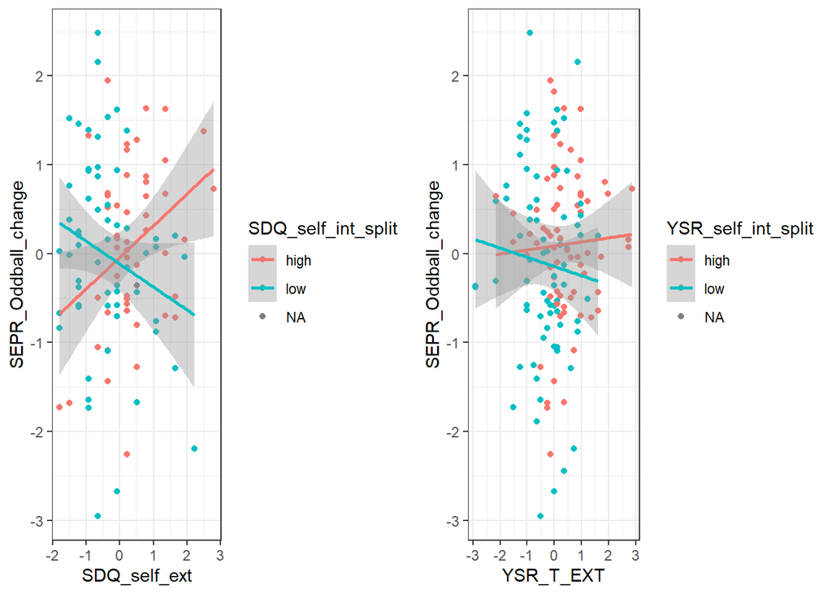

```r
df_scaled$SDQ_self_int_split<-ifelse(df_scaled$SDQ_self_int>=0,'high','low')
df_scaled$YSR_self_int_split<-ifelse(df_scaled$YSR_T_INT>=0,'high','low')

grid.arrange(
ggplot(df_scaled,aes(x=SDQ_self_ext,y=SEPR_Oddball_change,group=SDQ_self_int_split,color=SDQ_self_int_split))+
  geom_point()+
  geom_smooth(method='lm'),
ggplot(df_scaled,aes(x=YSR_T_EXT,y=SEPR_Oddball_change,group=YSR_self_int_split,color=YSR_self_int_split))+
  geom_point()+
  geom_smooth(method='lm'),ncol=2
)
```

### 1.6.6 effect of bio samples on pupillary response

investigating the magnitude and reactivity of pupillary measures

- higher saliva cortisol 1 is associated with lower baseline pupil size

```r
lm<-lm(BPS_average~saliva_Average.1+hair_cortisol_pg_mg+saliva_change+
         age+autism_boolean,data=df_scaled)
analyze_lm(lm)
```

```
## Anova Table (Type III tests)
##
## Response: BPS_average
##                     Sum Sq Df F value  Pr(>F)
## (Intercept)          0.005  1  0.0059 0.93909
## saliva_Average.1     3.689  1  4.5982 0.03504 *
## hair_cortisol_pg_mg  1.000  1  1.2470 0.26748
## saliva_change        1.135  1  1.4140 0.23790
## age                  1.120  1  1.3963 0.24085
## autism_boolean       1.145  1  1.4266 0.23585
## Residuals           64.186 80
## ---
## Signif. codes:  0 '***' 0.001 '**' 0.01 '*' 0.05 '.' 0.1 ' ' 1
```

```
##                           2.5 % 97.5 %
## (Intercept)          0.01 -0.24   0.26
## saliva_Average.1    -0.30 -0.58  -0.02
## hair_cortisol_pg_mg  0.11 -0.08   0.30
## saliva_change       -0.16 -0.44   0.11
## age                 -0.13 -0.35   0.09
## autism_booleanTRUE  -0.25 -0.66   0.17
```

```r
lm<-lm(BPS_change~saliva_Average.1+hair_cortisol_pg_mg+saliva_change+
         age+autism_boolean,data=df_scaled)
analyze_lm(lm)
```

```
## Anova Table (Type III tests)
##
## Response: BPS_change
##                     Sum Sq Df F value  Pr(>F)
## (Intercept)          0.009  1  0.0086 0.92638
## saliva_Average.1     2.503  1  2.4781 0.11911
## hair_cortisol_pg_mg  1.035  1  1.0250 0.31418
## saliva_change        0.857  1  0.8480 0.35970
## age                  5.657  1  5.6001 0.02021 *
## autism_boolean       0.248  1  0.2454 0.62161
## Residuals           86.878 86
## ---
## Signif. codes:  0 '***' 0.001 '**' 0.01 '*' 0.05 '.' 0.1 ' ' 1
```

```
##                           2.5 % 97.5 %
## (Intercept)          0.01 -0.26   0.29
## saliva_Average.1    -0.24 -0.55   0.06
## hair_cortisol_pg_mg  0.11 -0.10   0.32
## saliva_change       -0.14 -0.45   0.16
## age                 -0.28 -0.52  -0.05
## autism_booleanTRUE   0.11 -0.33   0.56
```

```r
lm<-lm(SEPR_average~saliva_Average.1+hair_cortisol_pg_mg+saliva_change+
         age+autism_boolean,data=df_scaled)
analyze_lm(lm)
```

```
## Anova Table (Type III tests)
##
## Response: SEPR_average
##                     Sum Sq Df F value  Pr(>F)
## (Intercept)          1.836  1  2.0216 0.15896
## saliva_Average.1     0.492  1  0.5412 0.46408
## hair_cortisol_pg_mg  0.052  1  0.0573 0.81147
## saliva_change        2.701  1  2.9739 0.08848 .
## age                  0.095  1  0.1051 0.74661
## autism_boolean       3.659  1  4.0289 0.04811 *
## Residuals           72.658 80
## ---
## Signif. codes:  0 '***' 0.001 '**' 0.01 '*' 0.05 '.' 0.1 ' ' 1
```

```
##                           2.5 % 97.5 %
## (Intercept)          0.19 -0.08   0.46
## saliva_Average.1    -0.11 -0.41   0.19
## hair_cortisol_pg_mg  0.02 -0.18   0.23
## saliva_change       -0.25 -0.55   0.04
## age                 -0.04 -0.27   0.20
## autism_booleanTRUE  -0.44 -0.88   0.00
```

```r
lm<-lm(SEPR_Oddball_change~saliva_Average.1+hair_cortisol_pg_mg+saliva_change+
         age+autism_boolean,data=df_scaled)
analyze_lm(lm)
```

```
## Anova Table (Type III tests)
##
## Response: SEPR_Oddball_change
##                     Sum Sq Df F value Pr(>F)
## (Intercept)          0.007  1  0.0066 0.9352
## saliva_Average.1     0.000  1  0.0001 0.9915
## hair_cortisol_pg_mg  0.027  1  0.0255 0.8735
## saliva_change        0.339  1  0.3191 0.5736
## age                  0.085  1  0.0798 0.7783
## autism_boolean       0.155  1  0.1458 0.7036
## Residuals           91.297 86
```

```
##                           2.5 % 97.5 %
## (Intercept)         -0.01 -0.29   0.27
## saliva_Average.1     0.00 -0.32   0.32
## hair_cortisol_pg_mg  0.02 -0.20   0.24
## saliva_change        0.09 -0.22   0.40
## age                 -0.03 -0.28   0.21
## autism_booleanTRUE   0.09 -0.37   0.54
```

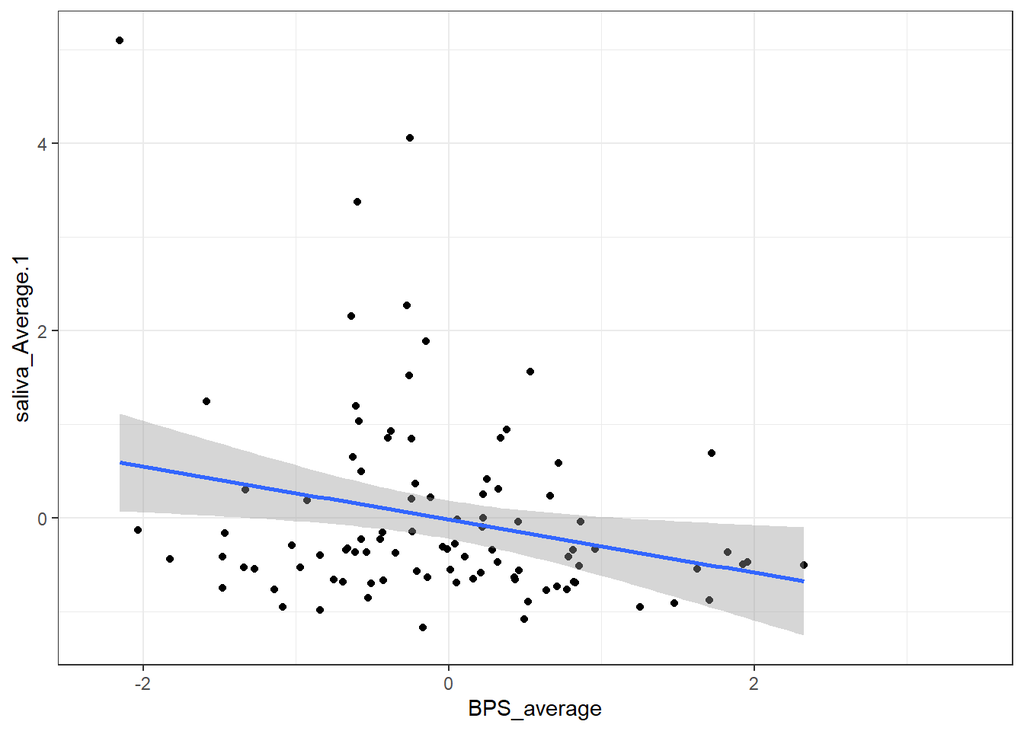

```r
ggplot(df_scaled,aes(x=BPS_average,y=saliva_Average.1))+
  geom_point()+
  geom_smooth(method='lm')
```

### 1.6.7 cortisol and pupillary measures explaining self-reported internalizing

- lower hair cortisol associated with higher internalizing psychopathology
- higher BPS is associated with higher internalizing
- the interaction suggests that this might be specifically relevant in groups of elevated symptoms
- pupillary measures might be a quantitative predictor of internalizing psychopathology in at-risk children

```r
lm1<-lm(YSR_T_INT~hair_cortisol_pg_mg+
         age+autism_boolean,data=df_scaled)
analyze_lm(lm1)
```

```
## Anova Table (Type III tests)
##
## Response: YSR_T_INT
##                     Sum Sq Df F value Pr(>F)
## (Intercept)          1.627  1  1.5752 0.2125
## hair_cortisol_pg_mg  6.389  1  6.1864 0.0146 *
## age                  6.926  1  6.7069 0.0111 *
## autism_boolean       0.063  1  0.0607 0.8059
## Residuals           99.141 96
## ---
## Signif. codes:  0 '***' 0.001 '**' 0.01 '*' 0.05 '.' 0.1 ' ' 1
```

```
##                           2.5 % 97.5 %
## (Intercept)          0.17 -0.10   0.44
## hair_cortisol_pg_mg -0.27 -0.48  -0.05
## age                  0.29  0.07   0.51
## autism_booleanTRUE  -0.05 -0.49   0.38
```

```r
summary(lm1)
```

```
##
## Call:
## lm(formula = YSR_T_INT ~ hair_cortisol_pg_mg + age + autism_boolean,
##     data = df_scaled)
##
## Residuals:
##     Min      1Q  Median      3Q     Max
## -2.9197 -0.5959 -0.1864  0.6548  2.4420
##
## Coefficients:
##                     Estimate Std. Error t value Pr(>|t|)
## (Intercept)           0.1720     0.1370   1.255   0.2125
## hair_cortisol_pg_mg  -0.2661     0.1070  -2.487   0.0146 *
## age                   0.2881     0.1113   2.590   0.0111 *
## autism_booleanTRUE   -0.0536     0.2175  -0.246   0.8059
## ---
## Signif. codes:  0 '***' 0.001 '**' 0.01 '*' 0.05 '.' 0.1 ' ' 1
##
## Residual standard error: 1.016 on 96 degrees of freedom
##   (58 observations deleted due to missingness)
## Multiple R-squared:  0.1019, Adjusted R-squared:  0.07383
## F-statistic:  3.63 on 3 and 96 DF,  p-value: 0.01567
```

```r
### R² = 0.10

lm1<-lm(YSR_T_INT~BPS_average+
         age+autism_boolean,data=df_scaled)
analyze_lm(lm1)
```

```
## Anova Table (Type III tests)
##
## Response: YSR_T_INT
##                 Sum Sq Df F value  Pr(>F)
## (Intercept)      0.439  1  0.3710 0.54397
## BPS_average      1.979  1  1.6724 0.19921
## age              5.450  1  4.6057 0.03453 *
## autism_boolean   1.252  1  1.0583 0.30634
## Residuals      107.687 91
## ---
## Signif. codes:  0 '***' 0.001 '**' 0.01 '*' 0.05 '.' 0.1 ' ' 1
```

```
##                         2.5 % 97.5 %
## (Intercept)        0.09 -0.20   0.37
## BPS_average        0.17 -0.09   0.43
## age                0.26  0.02   0.50
## autism_booleanTRUE 0.24 -0.22   0.71
```

```r
summary(lm1)
```

```
##
## Call:
## lm(formula = YSR_T_INT ~ BPS_average + age + autism_boolean,
##     data = df_scaled)
##
## Residuals:
##      Min       1Q   Median       3Q      Max
## -2.51929 -0.75340 -0.09093  0.74635  2.56543
##
## Coefficients:
##                    Estimate Std. Error t value Pr(>|t|)
## (Intercept)         0.08746    0.14358   0.609   0.5440
## BPS_average         0.16994    0.13141   1.293   0.1992
## age                 0.25809    0.12026   2.146   0.0345 *
## autism_booleanTRUE  0.24145    0.23471   1.029   0.3063
## ---
## Signif. codes:  0 '***' 0.001 '**' 0.01 '*' 0.05 '.' 0.1 ' ' 1
##
## Residual standard error: 1.088 on 91 degrees of freedom
##   (63 observations deleted due to missingness)
## Multiple R-squared:  0.06037,    Adjusted R-squared:  0.0294
## F-statistic: 1.949 on 3 and 91 DF,  p-value: 0.1273
```

```r
### R² = 0.06

lm2<-lm(YSR_T_INT~BPS_average*hair_cortisol_pg_mg+
         age+autism_boolean,data=df_scaled)
analyze_lm(lm2)
```

```
## Anova Table (Type III tests)
##
## Response: YSR_T_INT
##                                 Sum Sq Df F value  Pr(>F)
## (Intercept)                      2.302  1  2.1499 0.14636
## BPS_average                      4.277  1  3.9936 0.04895 *
## hair_cortisol_pg_mg              6.814  1  6.3635 0.01356 *
## age                              5.817  1  5.4319 0.02220 *
## autism_boolean                   0.056  1  0.0525 0.81926
## BPS_average:hair_cortisol_pg_mg  2.224  1  2.0767 0.15333
## Residuals                       88.882 83
## ---
## Signif. codes:  0 '***' 0.001 '**' 0.01 '*' 0.05 '.' 0.1 ' ' 1
```

```
##                                       2.5 % 97.5 %
## (Intercept)                      0.21 -0.08   0.50
## BPS_average                      0.26  0.00   0.52
## hair_cortisol_pg_mg             -0.28 -0.50  -0.06
## age                              0.29  0.04   0.53
## autism_booleanTRUE               0.05 -0.42   0.53
## BPS_average:hair_cortisol_pg_mg -0.15 -0.37   0.06
```

```r
summary(lm2)
```

```
##
## Call:
## lm(formula = YSR_T_INT ~ BPS_average * hair_cortisol_pg_mg +
##     age + autism_boolean, data = df_scaled)
##
## Residuals:
##      Min       1Q   Median       3Q      Max
## -2.50890 -0.67118 -0.06295  0.64877  2.55080
##
## Coefficients:
##                                 Estimate Std. Error t value Pr(>|t|)
## (Intercept)                      0.21316    0.14538   1.466   0.1464
## BPS_average                      0.26280    0.13151   1.998   0.0489 *
## hair_cortisol_pg_mg             -0.28202    0.11180  -2.523   0.0136 *
## age                              0.28769    0.12344   2.331   0.0222 *
## autism_booleanTRUE               0.05458    0.23810   0.229   0.8193
## BPS_average:hair_cortisol_pg_mg -0.15495    0.10752  -1.441   0.1533
## ---
## Signif. codes:  0 '***' 0.001 '**' 0.01 '*' 0.05 '.' 0.1 ' ' 1
##
## Residual standard error: 1.035 on 83 degrees of freedom
##   (69 observations deleted due to missingness)
## Multiple R-squared:  0.1511, Adjusted R-squared:    0.1
## F-statistic: 2.956 on 5 and 83 DF,  p-value: 0.01665
```

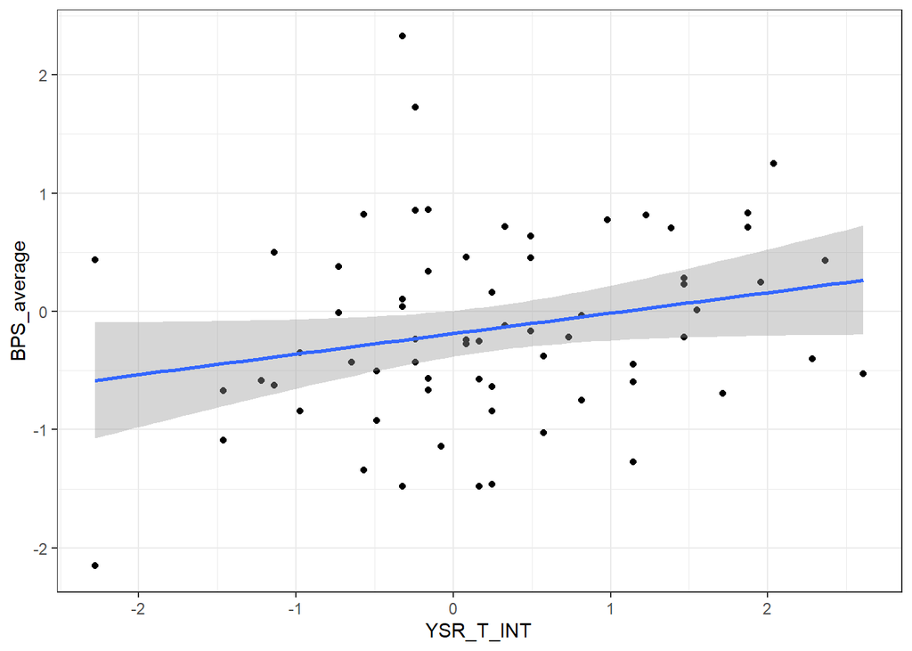

```r
### R² = 0.15


ggplot(df_scaled[df_scaled$hair_cortisol_pg_mg<0,],aes(x=YSR_T_INT,y=BPS_average))+geom_point()+geom_smooth(method='lm')
```

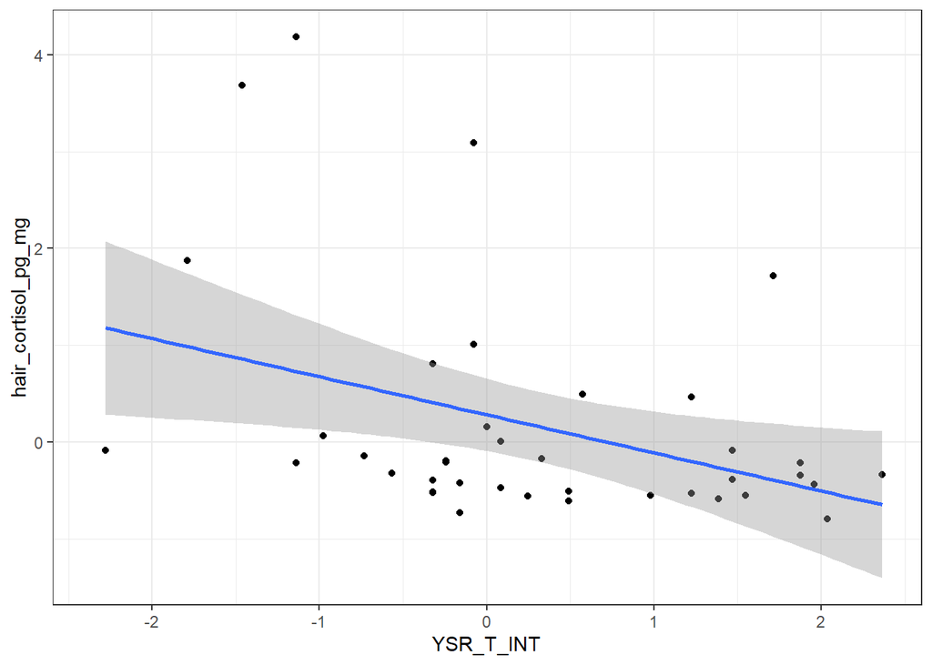

```r
ggplot(df_scaled[df_scaled$BPS_average>0,],aes(x=YSR_T_INT,y=hair_cortisol_pg_mg))+geom_point()+geom_smooth(method='lm')
```

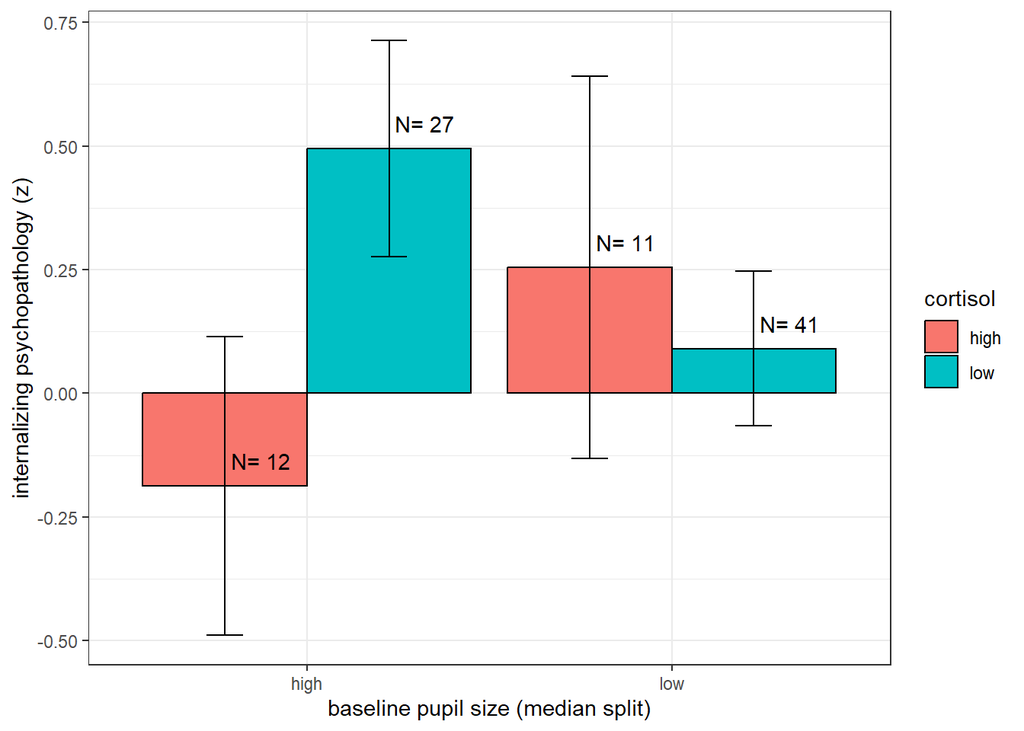

```r
#median split
df_scaled$hair_cortisol_split<-ifelse(df_scaled$hair_cortisol_pg_mg>=0,'high','low')
df_scaled$BPS_average_split<-ifelse(df_scaled$BPS_average>=0,'high','low')

#create plot data.frame - by groups
df_plot<-plyr::rbind.fill(by(df_scaled$YSR_T_INT,interaction(df_scaled$hair_cortisol_split,df_scaled$BPS_average_split),psych::describe))
df_plot$cortisol<-c('high','low','high','low')
df_plot$pupilsize<-c('high','high','low','low')


ggplot(df_plot,aes(x=pupilsize,y=mean,fill=cortisol))+
  geom_bar(position=position_dodge(), stat="identity", colour='black') +
  geom_errorbar(aes(ymin=mean-se, ymax=mean+se), width=.2,position=position_dodge(.9))+
  geom_text(aes(label=paste('N=',n)), vjust=-1, hjust=-0.1,position = position_dodge(width = .9))+
  xlab('baseline pupil size (median split)')+ylab('internalizing psychopathology (z)')
```